# Amazon Sales Analysis

## Importing important libraries for ETL. If more libraries are needed, we will add them later.

```python
import pandas as pd
import numpy as np
import matplotlib.pyplot as plt
```

## Importing amazon.csv sales file and saving it as a Dataframe labeled "amazonSales".

```python
amazonSales = pd.read_csv("amazon.csv")
```

## Showing first 5 rows in file.

```python
amazonSales.head(5)
```

|  | product_id | product_name | category | discounted_price | actual_price | discount_percentage | rating | rating_count | about_product | user_id | user_name | review_id | review_title | review_content | img_link | product_link |
| --- | --- | --- | --- | --- | --- | --- | --- | --- | --- | --- | --- | --- | --- | --- | --- | --- |
| 0 | B07JW9H4J1 | Wayona Nylon Braided USB to Lightning Fast Cha... | Computers&Accessories\|Accessories&Peripherals\|... | ₹399 | ₹1,099 | 64% | 4.2 | 24,269 | High Compatibility : Compatible With iPhone 12... | AG3D6O4STAQKAY2UVGEUV46KN35Q,AHMY5CWJMMK5BJRBB... | Manav,Adarsh gupta,Sundeep,S.Sayeed Ahmed,jasp... | R3HXWT0LRP0NMF,R2AJM3LFTLZHFO,R6AQJGUP6P86,R1K... | Satisfied,Charging is really fast,Value for mo... | Looks durable Charging is fine tooNo complains... | https://m.media-amazon.com/images/W/WEBP_40237... | https://www.amazon.in/Wayona-Braided-WN3LG1-Sy... |
| 1 | B098NS6PVG | Ambrane Unbreakable 60W / 3A Fast Charging 1.5... | Computers&Accessories\|Accessories&Peripherals\|... | ₹199 | ₹349 | 43% | 4.0 | 43,994 | Compatible with all Type C enabled devices, be... | AECPFYFQVRUWC3KGNLJIOREFP5LQ,AGYYVPDD7YG7FYNBX... | ArdKn,Nirbhay kumar,Sagar Viswanathan,Asp,Plac... | RGIQEG07R9HS2,R1SMWZQ86XIN8U,R2J3Y1WL29GWDE,RY... | A Good Braided Cable for Your Type C Device,Go... | I ordered this cable to connect my phone to An... | https://m.media-amazon.com/images/W/WEBP_40237... | https://www.amazon.in/Ambrane-Unbreakable-Char... |
| 2 | B096MSW6CT | Sounce Fast Phone Charging Cable & Data Sync U... | Computers&Accessories\|Accessories&Peripherals\|... | ₹199 | ₹1,899 | 90% | 3.9 | 7,928 | 【 Fast Charger& Data Sync】-With built-in safet... | AGU3BBQ2V2DDAMOAKGFAWDDQ6QHA,AESFLDV2PT363T2AQ... | Kunal,Himanshu,viswanath,sai niharka,saqib mal... | R3J3EQQ9TZI5ZJ,R3E7WBGK7ID0KV,RWU79XKQ6I1QF,R2... | Good speed for earlier versions,Good Product,W... | Not quite durable and sturdy,https://m.media-a... | https://m.media-amazon.com/images/W/WEBP_40237... | https://www.amazon.in/Sounce-iPhone-Charging-C... |
| 3 | B08HDJ86NZ | boAt Deuce USB 300 2 in 1 Type-C & Micro USB S... | Computers&Accessories\|Accessories&Peripherals\|... | ₹329 | ₹699 | 53% | 4.2 | 94,363 | The boAt Deuce USB 300 2 in 1 cable is compati... | AEWAZDZZJLQUYVOVGBEUKSLXHQ5A,AG5HTSFRRE6NL3M5S... | Omkar dhale,JD,HEMALATHA,Ajwadh a.,amar singh ... | R3EEUZKKK9J36I,R3HJVYCLYOY554,REDECAZ7AMPQC,R1... | Good product,Good one,Nice,Really nice product... | Good product,long wire,Charges good,Nice,I bou... | https://m.media-amazon.com/images/I/41V5FtEWPk... | https://www.amazon.in/Deuce-300-Resistant-Tang... |
| 4 | B08CF3B7N1 | Portronics Konnect L 1.2M Fast Charging 3A 8 P... | Computers&Accessories\|Accessories&Peripherals\|... | ₹154 | ₹399 | 61% | 4.2 | 16,905 | [CHARGE & SYNC FUNCTION]- This cable comes wit... | AE3Q6KSUK5P75D5HFYHCRAOLODSA,AFUGIFH5ZAFXRDSZH... | rahuls6099,Swasat Borah,Ajay Wadke,Pranali,RVK... | R1BP4L2HH9TFUP,R16PVJEXKV6QZS,R2UPDB81N66T4P,R... | As good as original,Decent,Good one for second... | Bought this instead of original apple, does th... | https://m.media-amazon.com/images/W/WEBP_40237... | https://www.amazon.in/Portronics-Konnect-POR-1... |

## Looking into the information of the Dataframe.

```python
amazonSales.info()
```

```
<class 'pandas.core.frame.DataFrame'>
RangeIndex: 1465 entries, 0 to 1464
Data columns (total 16 columns):
 #   Column               Non-Null Count  Dtype
---  ------               --------------  -----
 0   product_id           1465 non-null   object
 1   product_name         1465 non-null   object
 2   category             1465 non-null   object
 3   discounted_price     1465 non-null   object
 4   actual_price         1465 non-null   object
 5   discount_percentage  1465 non-null   object
 6   rating               1465 non-null   object
 7   rating_count         1463 non-null   object
 8   about_product        1465 non-null   object
 9   user_id              1465 non-null   object
 10  user_name            1465 non-null   object
 11  review_id            1465 non-null   object
 12  review_title         1465 non-null   object
 13  review_content       1465 non-null   object
 14  img_link             1465 non-null   object
 15  product_link         1465 non-null   object
dtypes: object(16)
memory usage: 183.2+ KB
```

## Realizing that all columns are of type "object". Columns like "product_id" are a mix of strings and numeric values, so these will need to be string types, and the numerical columns like "rating" need to be numerical, either int or float. Let's dive in.

```python
amazonSales["product_id"].dtype
```

```
dtype('O')
```

```python
amazonSales["rating"].dtype
```

```
dtype('O')
```

```python
rating = amazonSales["rating"]
```

```python
rating.dtype
```

```
dtype('O')
```

```python
rating.head(5)
```

```
0    4.2
1    4.0
2    3.9
3    4.2
4    4.2
Name: rating, dtype: object
```

```python
#Checking to see if the values can be converted to a float type, we get a "ValueError". This shows us
#that there is a non-numerical value of "|". (Running this code gives us a error, so it is commented
#out to prevent the entire notebook from not running).
# rating.astype(float)
```

```python
rating
```

```
0       4.2
1       4.0
2       3.9
3       4.2
4       4.2
       ...
1460      4
1461    4.1
1462    3.6
1463      4
1464    4.3
Name: rating, Length: 1465, dtype: object
```

## Showing value counts to see what resides in the column, and how many non-numerical data types are there.

```python
rating.value_counts()
```

```
4.1    244
4.3    230
4.2    228
4.0    129
3.9    123
4.4    123
3.8     86
4.5     75
4       52
3.7     42
3.6     35
3.5     26
4.6     17
3.3     16
3.4     10
4.7      6
3.1      4
5.0      3
3.0      3
4.8      3
3.2      2
2.8      2
2.3      1
|        1
2        1
3        1
2.6      1
2.9      1
Name: rating, dtype: int64
```

### Here, we will make a function that will change the column of choice (column_name) of the Dataframe (df) to all numeric values. All of the rows of the column that are non-numeric will be converted into NaN (Not a Number). Then, to convert it to a float, we do that with the `.astype()`. Lastly, we reset the index to ensure that it deletes the entire row to keep the data clean.

### First, we need to make a copy of the Dataframe so that any changes that we make, don't affect the original copy.

```python
amazonSales_1 = amazonSales.copy()
```

```python
def convert_column_to_float(df, column_name):
    """
    Convert a column in a DataFrame to numeric values, handling non-numeric values by
    converting them to NaN, and then change the data type to float.

    Parameters:
        df: pandas.DataFrame
            the DataFrame to be used.

        column_name:  str
            the column to be converted to float.

    Returns:
        pandas.DataFrame: The DataFrame with the specified column converted to float.
    """
    # Convert column to numeric, setting errors='coerce' to handle non-numeric values by converting them to NaN
    df[column_name] = pd.to_numeric(df[column_name], errors='coerce')

    # Drop rows where the specified column is NaN
    df.dropna(subset=[column_name], inplace=True)

    # Convert the column to float (optional, as it's likely already in float format after to_numeric)
    df[column_name] = df[column_name].astype(float)

    # Reset the index and drop the old index to avoid adding it as a column
    df.reset_index(drop=True, inplace=True)

    return df
```

```python
convert_column_to_float(amazonSales_1, "rating")
```

|  | product_id | product_name | category | discounted_price | actual_price | discount_percentage | rating | rating_count | about_product | user_id | user_name | review_id | review_title | review_content | img_link | product_link |
| --- | --- | --- | --- | --- | --- | --- | --- | --- | --- | --- | --- | --- | --- | --- | --- | --- |
| 0 | B07JW9H4J1 | Wayona Nylon Braided USB to Lightning Fast Cha... | Computers&Accessories\|Accessories&Peripherals\|... | ₹399 | ₹1,099 | 64% | 4.2 | 24,269 | High Compatibility : Compatible With iPhone 12... | AG3D6O4STAQKAY2UVGEUV46KN35Q,AHMY5CWJMMK5BJRBB... | Manav,Adarsh gupta,Sundeep,S.Sayeed Ahmed,jasp... | R3HXWT0LRP0NMF,R2AJM3LFTLZHFO,R6AQJGUP6P86,R1K... | Satisfied,Charging is really fast,Value for mo... | Looks durable Charging is fine tooNo complains... | https://m.media-amazon.com/images/W/WEBP_40237... | https://www.amazon.in/Wayona-Braided-WN3LG1-Sy... |
| 1 | B098NS6PVG | Ambrane Unbreakable 60W / 3A Fast Charging 1.5... | Computers&Accessories\|Accessories&Peripherals\|... | ₹199 | ₹349 | 43% | 4.0 | 43,994 | Compatible with all Type C enabled devices, be... | AECPFYFQVRUWC3KGNLJIOREFP5LQ,AGYYVPDD7YG7FYNBX... | ArdKn,Nirbhay kumar,Sagar Viswanathan,Asp,Plac... | RGIQEG07R9HS2,R1SMWZQ86XIN8U,R2J3Y1WL29GWDE,RY... | A Good Braided Cable for Your Type C Device,Go... | I ordered this cable to connect my phone to An... | https://m.media-amazon.com/images/W/WEBP_40237... | https://www.amazon.in/Ambrane-Unbreakable-Char... |
| 2 | B096MSW6CT | Sounce Fast Phone Charging Cable & Data Sync U... | Computers&Accessories\|Accessories&Peripherals\|... | ₹199 | ₹1,899 | 90% | 3.9 | 7,928 | 【 Fast Charger& Data Sync】-With built-in safet... | AGU3BBQ2V2DDAMOAKGFAWDDQ6QHA,AESFLDV2PT363T2AQ... | Kunal,Himanshu,viswanath,sai niharka,saqib mal... | R3J3EQQ9TZI5ZJ,R3E7WBGK7ID0KV,RWU79XKQ6I1QF,R2... | Good speed for earlier versions,Good Product,W... | Not quite durable and sturdy,https://m.media-a... | https://m.media-amazon.com/images/W/WEBP_40237... | https://www.amazon.in/Sounce-iPhone-Charging-C... |
| 3 | B08HDJ86NZ | boAt Deuce USB 300 2 in 1 Type-C & Micro USB S... | Computers&Accessories\|Accessories&Peripherals\|... | ₹329 | ₹699 | 53% | 4.2 | 94,363 | The boAt Deuce USB 300 2 in 1 cable is compati... | AEWAZDZZJLQUYVOVGBEUKSLXHQ5A,AG5HTSFRRE6NL3M5S... | Omkar dhale,JD,HEMALATHA,Ajwadh a.,amar singh ... | R3EEUZKKK9J36I,R3HJVYCLYOY554,REDECAZ7AMPQC,R1... | Good product,Good one,Nice,Really nice product... | Good product,long wire,Charges good,Nice,I bou... | https://m.media-amazon.com/images/I/41V5FtEWPk... | https://www.amazon.in/Deuce-300-Resistant-Tang... |
| 4 | B08CF3B7N1 | Portronics Konnect L 1.2M Fast Charging 3A 8 P... | Computers&Accessories\|Accessories&Peripherals\|... | ₹154 | ₹399 | 61% | 4.2 | 16,905 | [CHARGE & SYNC FUNCTION]- This cable comes wit... | AE3Q6KSUK5P75D5HFYHCRAOLODSA,AFUGIFH5ZAFXRDSZH... | rahuls6099,Swasat Borah,Ajay Wadke,Pranali,RVK... | R1BP4L2HH9TFUP,R16PVJEXKV6QZS,R2UPDB81N66T4P,R... | As good as original,Decent,Good one for second... | Bought this instead of original apple, does th... | https://m.media-amazon.com/images/W/WEBP_40237... | https://www.amazon.in/Portronics-Konnect-POR-1... |
| ... | ... | ... | ... | ... | ... | ... | ... | ... | ... | ... | ... | ... | ... | ... | ... | ... |
| 1459 | B08L7J3T31 | Noir Aqua - 5pcs PP Spun Filter + 1 Spanner \| ... | Home&Kitchen\|Kitchen&HomeAppliances\|WaterPurif... | ₹379 | ₹919 | 59% | 4.0 | 1,090 | SUPREME QUALITY 90 GRAM 3 LAYER THIK PP SPUN F... | AHITFY6AHALOFOHOZEOC6XBP4FEA,AFRABBODZJZQB6Z4U... | Prabha ds,Raghuram bk,Real Deal,Amazon Custome... | R3G3XFHPBFF0E8,R3C0BZCD32EIGW,R2EBVBCN9QPD9R,R... | Received the product without spanner,Excellent... | I received product without spanner,Excellent p... | https://m.media-amazon.com/images/I/41fDdRtjfx... | https://www.amazon.in/Noir-Aqua-Spanner-Purifi... |
| 1460 | B01M6453MB | Prestige Delight PRWO Electric Rice Cooker (1 ... | Home&Kitchen\|Kitchen&HomeAppliances\|SmallKitch... | ₹2,280 | ₹3,045 | 25% | 4.1 | 4,118 | 230 Volts, 400 watts, 1 Year | AFG5FM3NEMOL6BNFRV2NK5FNJCHQ,AGEINTRN6Z563RMLH... | Manu Bhai,Naveenpittu,Evatira Sangma,JAGANNADH... | R3DDL2UPKQ2CK9,R2SYYU1OATVIU5,R1VM993161IYRW,R... | ok,everything was good couldn't return bcoz I ... | ok,got everything as mentioned but the measuri... | https://m.media-amazon.com/images/I/41gzDxk4+k... | https://www.amazon.in/Prestige-Delight-PRWO-1-... |
| 1461 | B009P2LIL4 | Bajaj Majesty RX10 2000 Watts Heat Convector R... | Home&Kitchen\|Heating,Cooling&AirQuality\|RoomHe... | ₹2,219 | ₹3,080 | 28% | 3.6 | 468 | International design and styling\|Two heat sett... | AGVPWCMAHYQWJOQKMUJN4DW3KM5Q,AF4Q3E66MY4SR7YQZ... | Nehal Desai,Danish Parwez,Amazon Customer,Amaz... | R1TLRJVW4STY5I,R2O455KRN493R1,R3Q5MVGBRIAS2G,R... | very good,Work but front melt after 2 month,Go... | plastic but cool body ,u have to find sturdy s... | https://m.media-amazon.com/images/W/WEBP_40237... | https://www.amazon.in/Bajaj-RX-10-2000-Watt-Co... |
| 1462 | B00J5DYCCA | Havells Ventil Air DSP 230mm Exhaust Fan (Pist... | Home&Kitchen\|Heating,Cooling&AirQuality\|Fans\|E... | ₹1,399 | ₹1,890 | 26% | 4.0 | 8,031 | Fan sweep area: 230 MM ; Noise level: (40 - 45... | AF2JQCLSCY3QJATWUNNHUSVUPNQQ,AFDMLUXC5LS5RXDJS... | Shubham Dubey,E.GURUBARAN,Mayank S.,eusuf khan... | R39Q2Y79MM9SWK,R3079BG1NIH6MB,R29A31ZELTZNJM,R... | Fan Speed is slow,Good quality,Good product,go... | I have installed this in my kitchen working fi... | https://m.media-amazon.com/images/W/WEBP_40237... | https://www.amazon.in/Havells-Ventilair-230mm-... |
| 1463 | B01486F4G6 | Borosil Jumbo 1000-Watt Grill Sandwich Maker (... | Home&Kitchen\|Kitchen&HomeAppliances\|SmallKitch... | ₹2,863 | ₹3,690 | 22% | 4.3 | 6,987 | Brand-Borosil, Specification â€“ 23V ~ 5Hz;1 W... | AFGW5PT3R6ZAVQR4Y5MWVAKBZAYA,AG7QNJ2SCS5VS5VYY... | Rajib,Ajay B,Vikas Kahol,PARDEEP,Anindya Prama... | R20RBRZ0WEUJT9,ROKIFK9R2ISSE,R30EEG2FNJSN5I,R2... | Works perfect,Ok good product,Nice Product. Re... | It does it job perfectly..only issue is temp c... | https://m.media-amazon.com/images/W/WEBP_40237... | https://www.amazon.in/Borosil-Jumbo-1000-Watt-... |

1464 rows × 16 columns

### Here we see that the index has reset, this is just for proof of work. We also knew where the non-numerical data was ahead of time in the column (index of 1279) and so we're just checking to see that it is gone. Hence why we're looking in this area.

```python
amazonSales_1.rating[1277:1283]
```

```
1277    3.8
1278    4.1
1279    4.1
1280    3.9
1281    3.8
1282    4.1
Name: rating, dtype: float64
```

### And we can also see that the column is now a float instead of an object, and has the correct amount of entries with the one row deleted.

```python
amazonSales_1.rating.info()
```

```
<class 'pandas.core.series.Series'>
RangeIndex: 1464 entries, 0 to 1463
Series name: rating
Non-Null Count  Dtype
--------------  -----
1464 non-null   float64
dtypes: float64(1)
memory usage: 11.6 KB
```

### Now we will do the same process, only we will fill the NaN with the mean (average) of the entire column. The last step that is also added is the rounding step. This ensures that only one digit will be saved and displayed after the averaging process.

### Like last time, we will make a copy of the Dataframe.

```python
amazonSales_2 = amazonSales.copy()
```

```python
def convert_column_to_float_fillna_with_mean(df, column_name):
    """
    Convert a column in a DataFrame to numeric values, converting non-numeric values to NaN,
    and then change the data type to float. NaN values are then replaced with
    the average of the column.

    Parameters:
        df: pandas.DataFrame
            The DataFrame to be used.
        column_name: str
            The name of the column to convert.

    Returns:
        pandas.DataFrame
            The DataFrame with the specified column converted to float and NaN filled with the
            column's average.
    """
    # Convert column to numeric, setting errors='coerce' to handle non-numeric values by converting them to NaN
    df[column_name] = pd.to_numeric(df[column_name], errors='coerce')

    # Calculate the mean of the column, excluding NaN values
    mean_value = df[column_name].mean()

    # Fill NaN values in the column with the calculated mean
    df[column_name].fillna(value=mean_value, inplace=True)

    # Round the column values to 1 decimal place
    df[column_name] = df[column_name].round(1)

    return df
```

```python
convert_column_to_float_fillna_with_mean(amazonSales_2, "rating")
```

|  | product_id | product_name | category | discounted_price | actual_price | discount_percentage | rating | rating_count | about_product | user_id | user_name | review_id | review_title | review_content | img_link | product_link |
| --- | --- | --- | --- | --- | --- | --- | --- | --- | --- | --- | --- | --- | --- | --- | --- | --- |
| 0 | B07JW9H4J1 | Wayona Nylon Braided USB to Lightning Fast Cha... | Computers&Accessories\|Accessories&Peripherals\|... | ₹399 | ₹1,099 | 64% | 4.2 | 24,269 | High Compatibility : Compatible With iPhone 12... | AG3D6O4STAQKAY2UVGEUV46KN35Q,AHMY5CWJMMK5BJRBB... | Manav,Adarsh gupta,Sundeep,S.Sayeed Ahmed,jasp... | R3HXWT0LRP0NMF,R2AJM3LFTLZHFO,R6AQJGUP6P86,R1K... | Satisfied,Charging is really fast,Value for mo... | Looks durable Charging is fine tooNo complains... | https://m.media-amazon.com/images/W/WEBP_40237... | https://www.amazon.in/Wayona-Braided-WN3LG1-Sy... |
| 1 | B098NS6PVG | Ambrane Unbreakable 60W / 3A Fast Charging 1.5... | Computers&Accessories\|Accessories&Peripherals\|... | ₹199 | ₹349 | 43% | 4.0 | 43,994 | Compatible with all Type C enabled devices, be... | AECPFYFQVRUWC3KGNLJIOREFP5LQ,AGYYVPDD7YG7FYNBX... | ArdKn,Nirbhay kumar,Sagar Viswanathan,Asp,Plac... | RGIQEG07R9HS2,R1SMWZQ86XIN8U,R2J3Y1WL29GWDE,RY... | A Good Braided Cable for Your Type C Device,Go... | I ordered this cable to connect my phone to An... | https://m.media-amazon.com/images/W/WEBP_40237... | https://www.amazon.in/Ambrane-Unbreakable-Char... |
| 2 | B096MSW6CT | Sounce Fast Phone Charging Cable & Data Sync U... | Computers&Accessories\|Accessories&Peripherals\|... | ₹199 | ₹1,899 | 90% | 3.9 | 7,928 | 【 Fast Charger& Data Sync】-With built-in safet... | AGU3BBQ2V2DDAMOAKGFAWDDQ6QHA,AESFLDV2PT363T2AQ... | Kunal,Himanshu,viswanath,sai niharka,saqib mal... | R3J3EQQ9TZI5ZJ,R3E7WBGK7ID0KV,RWU79XKQ6I1QF,R2... | Good speed for earlier versions,Good Product,W... | Not quite durable and sturdy,https://m.media-a... | https://m.media-amazon.com/images/W/WEBP_40237... | https://www.amazon.in/Sounce-iPhone-Charging-C... |
| 3 | B08HDJ86NZ | boAt Deuce USB 300 2 in 1 Type-C & Micro USB S... | Computers&Accessories\|Accessories&Peripherals\|... | ₹329 | ₹699 | 53% | 4.2 | 94,363 | The boAt Deuce USB 300 2 in 1 cable is compati... | AEWAZDZZJLQUYVOVGBEUKSLXHQ5A,AG5HTSFRRE6NL3M5S... | Omkar dhale,JD,HEMALATHA,Ajwadh a.,amar singh ... | R3EEUZKKK9J36I,R3HJVYCLYOY554,REDECAZ7AMPQC,R1... | Good product,Good one,Nice,Really nice product... | Good product,long wire,Charges good,Nice,I bou... | https://m.media-amazon.com/images/I/41V5FtEWPk... | https://www.amazon.in/Deuce-300-Resistant-Tang... |
| 4 | B08CF3B7N1 | Portronics Konnect L 1.2M Fast Charging 3A 8 P... | Computers&Accessories\|Accessories&Peripherals\|... | ₹154 | ₹399 | 61% | 4.2 | 16,905 | [CHARGE & SYNC FUNCTION]- This cable comes wit... | AE3Q6KSUK5P75D5HFYHCRAOLODSA,AFUGIFH5ZAFXRDSZH... | rahuls6099,Swasat Borah,Ajay Wadke,Pranali,RVK... | R1BP4L2HH9TFUP,R16PVJEXKV6QZS,R2UPDB81N66T4P,R... | As good as original,Decent,Good one for second... | Bought this instead of original apple, does th... | https://m.media-amazon.com/images/W/WEBP_40237... | https://www.amazon.in/Portronics-Konnect-POR-1... |
| ... | ... | ... | ... | ... | ... | ... | ... | ... | ... | ... | ... | ... | ... | ... | ... | ... |
| 1460 | B08L7J3T31 | Noir Aqua - 5pcs PP Spun Filter + 1 Spanner \| ... | Home&Kitchen\|Kitchen&HomeAppliances\|WaterPurif... | ₹379 | ₹919 | 59% | 4.0 | 1,090 | SUPREME QUALITY 90 GRAM 3 LAYER THIK PP SPUN F... | AHITFY6AHALOFOHOZEOC6XBP4FEA,AFRABBODZJZQB6Z4U... | Prabha ds,Raghuram bk,Real Deal,Amazon Custome... | R3G3XFHPBFF0E8,R3C0BZCD32EIGW,R2EBVBCN9QPD9R,R... | Received the product without spanner,Excellent... | I received product without spanner,Excellent p... | https://m.media-amazon.com/images/I/41fDdRtjfx... | https://www.amazon.in/Noir-Aqua-Spanner-Purifi... |
| 1461 | B01M6453MB | Prestige Delight PRWO Electric Rice Cooker (1 ... | Home&Kitchen\|Kitchen&HomeAppliances\|SmallKitch... | ₹2,280 | ₹3,045 | 25% | 4.1 | 4,118 | 230 Volts, 400 watts, 1 Year | AFG5FM3NEMOL6BNFRV2NK5FNJCHQ,AGEINTRN6Z563RMLH... | Manu Bhai,Naveenpittu,Evatira Sangma,JAGANNADH... | R3DDL2UPKQ2CK9,R2SYYU1OATVIU5,R1VM993161IYRW,R... | ok,everything was good couldn't return bcoz I ... | ok,got everything as mentioned but the measuri... | https://m.media-amazon.com/images/I/41gzDxk4+k... | https://www.amazon.in/Prestige-Delight-PRWO-1-... |
| 1462 | B009P2LIL4 | Bajaj Majesty RX10 2000 Watts Heat Convector R... | Home&Kitchen\|Heating,Cooling&AirQuality\|RoomHe... | ₹2,219 | ₹3,080 | 28% | 3.6 | 468 | International design and styling\|Two heat sett... | AGVPWCMAHYQWJOQKMUJN4DW3KM5Q,AF4Q3E66MY4SR7YQZ... | Nehal Desai,Danish Parwez,Amazon Customer,Amaz... | R1TLRJVW4STY5I,R2O455KRN493R1,R3Q5MVGBRIAS2G,R... | very good,Work but front melt after 2 month,Go... | plastic but cool body ,u have to find sturdy s... | https://m.media-amazon.com/images/W/WEBP_40237... | https://www.amazon.in/Bajaj-RX-10-2000-Watt-Co... |
| 1463 | B00J5DYCCA | Havells Ventil Air DSP 230mm Exhaust Fan (Pist... | Home&Kitchen\|Heating,Cooling&AirQuality\|Fans\|E... | ₹1,399 | ₹1,890 | 26% | 4.0 | 8,031 | Fan sweep area: 230 MM ; Noise level: (40 - 45... | AF2JQCLSCY3QJATWUNNHUSVUPNQQ,AFDMLUXC5LS5RXDJS... | Shubham Dubey,E.GURUBARAN,Mayank S.,eusuf khan... | R39Q2Y79MM9SWK,R3079BG1NIH6MB,R29A31ZELTZNJM,R... | Fan Speed is slow,Good quality,Good product,go... | I have installed this in my kitchen working fi... | https://m.media-amazon.com/images/W/WEBP_40237... | https://www.amazon.in/Havells-Ventilair-230mm-... |
| 1464 | B01486F4G6 | Borosil Jumbo 1000-Watt Grill Sandwich Maker (... | Home&Kitchen\|Kitchen&HomeAppliances\|SmallKitch... | ₹2,863 | ₹3,690 | 22% | 4.3 | 6,987 | Brand-Borosil, Specification â€“ 23V ~ 5Hz;1 W... | AFGW5PT3R6ZAVQR4Y5MWVAKBZAYA,AG7QNJ2SCS5VS5VYY... | Rajib,Ajay B,Vikas Kahol,PARDEEP,Anindya Prama... | R20RBRZ0WEUJT9,ROKIFK9R2ISSE,R30EEG2FNJSN5I,R2... | Works perfect,Ok good product,Nice Product. Re... | It does it job perfectly..only issue is temp c... | https://m.media-amazon.com/images/W/WEBP_40237... | https://www.amazon.in/Borosil-Jumbo-1000-Watt-... |

1465 rows × 16 columns

```python
amazonSales_2.rating[1277:1283]
```

```
1277    3.8
1278    4.1
1279    4.1
1280    4.1
1281    3.9
1282    3.8
Name: rating, dtype: float64
```

### So the pros and cons:

- The pro of deleting the contaminated rows - keeps the data clean with no bias (mean, median or mode) injected into the dataset
- The con of deleting the contaminated rows - if there is not enough data, it can give less accurate results by deleting the rows.
- The pro of filling with average - helps to fill in the missing data to keep deleted data to a minimum, which allows for closer approximation of the missing data. This can help when modelling the data, which can help spot things like outliers.
- The con of filling with average - may add some accidental bias into the dataset that was not there in the beginning.

### There are also other ways to fill in the missing data, like using 'SimpleImputer' provided by scikit-learn, but we will use that for another dataset when modeling. For now, we will just use what we have now since we're just analyzing the data.

### Since there is plenty of data in the dataset, and there is only one row to be deleted, we can then choose to delete the data to keep the data as clean as possible

### Let's take a look at the other columns to see if we can convert anything else.

```python
amazonSales.head(10)
```

|  | product_id | product_name | category | discounted_price | actual_price | discount_percentage | rating | rating_count | about_product | user_id | user_name | review_id | review_title | review_content | img_link | product_link |
| --- | --- | --- | --- | --- | --- | --- | --- | --- | --- | --- | --- | --- | --- | --- | --- | --- |
| 0 | B07JW9H4J1 | Wayona Nylon Braided USB to Lightning Fast Cha... | Computers&Accessories\|Accessories&Peripherals\|... | ₹399 | ₹1,099 | 64% | 4.2 | 24,269 | High Compatibility : Compatible With iPhone 12... | AG3D6O4STAQKAY2UVGEUV46KN35Q,AHMY5CWJMMK5BJRBB... | Manav,Adarsh gupta,Sundeep,S.Sayeed Ahmed,jasp... | R3HXWT0LRP0NMF,R2AJM3LFTLZHFO,R6AQJGUP6P86,R1K... | Satisfied,Charging is really fast,Value for mo... | Looks durable Charging is fine tooNo complains... | https://m.media-amazon.com/images/W/WEBP_40237... | https://www.amazon.in/Wayona-Braided-WN3LG1-Sy... |
| 1 | B098NS6PVG | Ambrane Unbreakable 60W / 3A Fast Charging 1.5... | Computers&Accessories\|Accessories&Peripherals\|... | ₹199 | ₹349 | 43% | 4.0 | 43,994 | Compatible with all Type C enabled devices, be... | AECPFYFQVRUWC3KGNLJIOREFP5LQ,AGYYVPDD7YG7FYNBX... | ArdKn,Nirbhay kumar,Sagar Viswanathan,Asp,Plac... | RGIQEG07R9HS2,R1SMWZQ86XIN8U,R2J3Y1WL29GWDE,RY... | A Good Braided Cable for Your Type C Device,Go... | I ordered this cable to connect my phone to An... | https://m.media-amazon.com/images/W/WEBP_40237... | https://www.amazon.in/Ambrane-Unbreakable-Char... |
| 2 | B096MSW6CT | Sounce Fast Phone Charging Cable & Data Sync U... | Computers&Accessories\|Accessories&Peripherals\|... | ₹199 | ₹1,899 | 90% | 3.9 | 7,928 | 【 Fast Charger& Data Sync】-With built-in safet... | AGU3BBQ2V2DDAMOAKGFAWDDQ6QHA,AESFLDV2PT363T2AQ... | Kunal,Himanshu,viswanath,sai niharka,saqib mal... | R3J3EQQ9TZI5ZJ,R3E7WBGK7ID0KV,RWU79XKQ6I1QF,R2... | Good speed for earlier versions,Good Product,W... | Not quite durable and sturdy,https://m.media-a... | https://m.media-amazon.com/images/W/WEBP_40237... | https://www.amazon.in/Sounce-iPhone-Charging-C... |
| 3 | B08HDJ86NZ | boAt Deuce USB 300 2 in 1 Type-C & Micro USB S... | Computers&Accessories\|Accessories&Peripherals\|... | ₹329 | ₹699 | 53% | 4.2 | 94,363 | The boAt Deuce USB 300 2 in 1 cable is compati... | AEWAZDZZJLQUYVOVGBEUKSLXHQ5A,AG5HTSFRRE6NL3M5S... | Omkar dhale,JD,HEMALATHA,Ajwadh a.,amar singh ... | R3EEUZKKK9J36I,R3HJVYCLYOY554,REDECAZ7AMPQC,R1... | Good product,Good one,Nice,Really nice product... | Good product,long wire,Charges good,Nice,I bou... | https://m.media-amazon.com/images/I/41V5FtEWPk... | https://www.amazon.in/Deuce-300-Resistant-Tang... |
| 4 | B08CF3B7N1 | Portronics Konnect L 1.2M Fast Charging 3A 8 P... | Computers&Accessories\|Accessories&Peripherals\|... | ₹154 | ₹399 | 61% | 4.2 | 16,905 | [CHARGE & SYNC FUNCTION]- This cable comes wit... | AE3Q6KSUK5P75D5HFYHCRAOLODSA,AFUGIFH5ZAFXRDSZH... | rahuls6099,Swasat Borah,Ajay Wadke,Pranali,RVK... | R1BP4L2HH9TFUP,R16PVJEXKV6QZS,R2UPDB81N66T4P,R... | As good as original,Decent,Good one for second... | Bought this instead of original apple, does th... | https://m.media-amazon.com/images/W/WEBP_40237... | https://www.amazon.in/Portronics-Konnect-POR-1... |
| 5 | B08Y1TFSP6 | pTron Solero TB301 3A Type-C Data and Fast Cha... | Computers&Accessories\|Accessories&Peripherals\|... | ₹149 | ₹1,000 | 85% | 3.9 | 24,871 | Fast Charging & Data Sync: Solero TB301 Type-C... | AEQ2YMXSZWEOHK2EHTNLOS56YTZQ,AGRVINWECNY7323CW... | Jayesh,Rajesh k.,Soopy,amazon customer,Aman,Sh... | R7S8ANNSDPR40,R3CLZFLHVJU26P,RFF7U7MPQFUGR,R1M... | It's pretty good,Average quality,very good and... | It's a good product.,Like,Very good item stron... | https://m.media-amazon.com/images/I/31wOPjcSxl... | https://www.amazon.in/Solero-TB301-Charging-48... |
| 6 | B08WRWPM22 | boAt Micro USB 55 Tangle-free, Sturdy Micro US... | Computers&Accessories\|Accessories&Peripherals\|... | ₹176.63 | ₹499 | 65% | 4.1 | 15,188 | It Ensures High Speed Transmission And Chargin... | AG7C6DAADCTRQJG2BRS3RIKDT52Q,AFU7BOMPVJ7Q3TTA4... | Vivek kumar,Amazon Customer,SARTHAK,Chiranjeev... | R8E73K2KWJRDS,RSD0JTIIWQQL8,R64CRSTE9SLW1,R2FR... | Long durable.,good,Does not charge Lenovo m8 t... | Build quality is good and it is comes with 2 y... | https://m.media-amazon.com/images/W/WEBP_40237... | https://www.amazon.in/boAt-Micro-USB-Tangle-Fr... |
| 7 | B08DDRGWTJ | MI Usb Type-C Cable Smartphone (Black) | Computers&Accessories\|Accessories&Peripherals\|... | ₹229 | ₹299 | 23% | 4.3 | 30,411 | 1m long Type-C USB Cable\|Sturdy and Durable. W... | AHW6E5LQ2BDYOIVLAJGDH45J5V5Q,AF74RSGCHPZITVFSZ... | Pavan A H,Jayesh bagad,Shridhar,rajendran,karu... | R2X090D1YHACKR,R32ZCIH9AFNJ60,R3N57EVVG0EHAF,R... | Worth for money - suitable for Android auto,Go... | Worth for money - suitable for Android auto...... | https://m.media-amazon.com/images/I/31XO-wfGGG... | https://www.amazon.in/MI-MTCY001IN-USB-Type-C-... |
| 8 | B008IFXQFU | TP-Link USB WiFi Adapter for PC(TL-WN725N), N1... | Computers&Accessories\|NetworkingDevices\|Networ... | ₹499 | ₹999 | 50% | 4.2 | 1,79,691 | USB WiFi Adapter —— Speedy wireless transmissi... | AGV3IEFANZCKECFGUM42MRH5FNOA,AEBO7NWCNXKT4AESA... | Azhar JuMan,Anirudh Sood,Hari Krishnan PS,Akas... | R1LW6NWSVTVZ2H,R3VR5WFKUS15C5,R2F6GC79OYWUKQ,R... | Works on linux for me. Get the model with ante... | I use this to connect an old PC to internet. I... | https://m.media-amazon.com/images/W/WEBP_40237... | https://www.amazon.in/TP-Link-TL-WN725N-150Mbp... |
| 9 | B082LZGK39 | Ambrane Unbreakable 60W / 3A Fast Charging 1.5... | Computers&Accessories\|Accessories&Peripherals\|... | ₹199 | ₹299 | 33% | 4.0 | 43,994 | Universal Compatibility – It is compatible wit... | AECPFYFQVRUWC3KGNLJIOREFP5LQ,AGYYVPDD7YG7FYNBX... | ArdKn,Nirbhay kumar,Sagar Viswanathan,Asp,Plac... | RGIQEG07R9HS2,R1SMWZQ86XIN8U,R2J3Y1WL29GWDE,RY... | A Good Braided Cable for Your Type C Device,Go... | I ordered this cable to connect my phone to An... | https://m.media-amazon.com/images/W/WEBP_40237... | https://www.amazon.in/Ambrane-Unbreakable-Char... |

### It looks like 'rating_count' is comprised of just integers, so let's convert that column to integers. Keeping in mind that we need to be mindful of the commas in the larger numbers. If not, we may accidentally erase numbers larger than 999.

```python
def convert_column_to_int(df, column_name):
    '''
    Convert the column from the dataframe to pure numeric data, any non-numeric data will be converted to
    NaN, the NaN's will be deleted, and the remaining numeric data will be converted to integers. All
    commas will be deleted to prevent any deletion of numbers higher than 999. (Ex: 1,000)

    Parameters:
        df: pandas.DataFrame
            The DataFrame to be used.

        column_name: str
            The column to be converted to int.

    Returns:
        pandas.DataFrame
            The DataFrame with the specified column converted to int.
    '''
    # Convert the column to string, remove the commas, convert column to numeric,
    # setting errors='coerce' to handle non-numeric values by converting them to NaN
    df[column_name] = df[column_name].astype(str).str.replace(',', '').apply(pd.to_numeric, errors='coerce')

    # Drop rows where the specified column is NaN
    df.dropna(subset=[column_name], inplace=True)

    # Convert the column to int
    df[column_name] = df[column_name].astype(int)

    # Reset the index and drop the old index to avoid adding it as a column
    df.reset_index(drop=True, inplace=True)

    return df
```

### We will go back to the copy of 'amazonSales', 'amazonSales_1', since this is the dataset we have been deleteing rows from. We still want to preserve the original for any future reference or any goal changes.

```python
convert_column_to_int(amazonSales_1, 'rating_count')
```

|  | product_id | product_name | category | discounted_price | actual_price | discount_percentage | rating | rating_count | about_product | user_id | user_name | review_id | review_title | review_content | img_link | product_link |
| --- | --- | --- | --- | --- | --- | --- | --- | --- | --- | --- | --- | --- | --- | --- | --- | --- |
| 0 | B07JW9H4J1 | Wayona Nylon Braided USB to Lightning Fast Cha... | Computers&Accessories\|Accessories&Peripherals\|... | ₹399 | ₹1,099 | 64% | 4.2 | 24269 | High Compatibility : Compatible With iPhone 12... | AG3D6O4STAQKAY2UVGEUV46KN35Q,AHMY5CWJMMK5BJRBB... | Manav,Adarsh gupta,Sundeep,S.Sayeed Ahmed,jasp... | R3HXWT0LRP0NMF,R2AJM3LFTLZHFO,R6AQJGUP6P86,R1K... | Satisfied,Charging is really fast,Value for mo... | Looks durable Charging is fine tooNo complains... | https://m.media-amazon.com/images/W/WEBP_40237... | https://www.amazon.in/Wayona-Braided-WN3LG1-Sy... |
| 1 | B098NS6PVG | Ambrane Unbreakable 60W / 3A Fast Charging 1.5... | Computers&Accessories\|Accessories&Peripherals\|... | ₹199 | ₹349 | 43% | 4.0 | 43994 | Compatible with all Type C enabled devices, be... | AECPFYFQVRUWC3KGNLJIOREFP5LQ,AGYYVPDD7YG7FYNBX... | ArdKn,Nirbhay kumar,Sagar Viswanathan,Asp,Plac... | RGIQEG07R9HS2,R1SMWZQ86XIN8U,R2J3Y1WL29GWDE,RY... | A Good Braided Cable for Your Type C Device,Go... | I ordered this cable to connect my phone to An... | https://m.media-amazon.com/images/W/WEBP_40237... | https://www.amazon.in/Ambrane-Unbreakable-Char... |
| 2 | B096MSW6CT | Sounce Fast Phone Charging Cable & Data Sync U... | Computers&Accessories\|Accessories&Peripherals\|... | ₹199 | ₹1,899 | 90% | 3.9 | 7928 | 【 Fast Charger& Data Sync】-With built-in safet... | AGU3BBQ2V2DDAMOAKGFAWDDQ6QHA,AESFLDV2PT363T2AQ... | Kunal,Himanshu,viswanath,sai niharka,saqib mal... | R3J3EQQ9TZI5ZJ,R3E7WBGK7ID0KV,RWU79XKQ6I1QF,R2... | Good speed for earlier versions,Good Product,W... | Not quite durable and sturdy,https://m.media-a... | https://m.media-amazon.com/images/W/WEBP_40237... | https://www.amazon.in/Sounce-iPhone-Charging-C... |
| 3 | B08HDJ86NZ | boAt Deuce USB 300 2 in 1 Type-C & Micro USB S... | Computers&Accessories\|Accessories&Peripherals\|... | ₹329 | ₹699 | 53% | 4.2 | 94363 | The boAt Deuce USB 300 2 in 1 cable is compati... | AEWAZDZZJLQUYVOVGBEUKSLXHQ5A,AG5HTSFRRE6NL3M5S... | Omkar dhale,JD,HEMALATHA,Ajwadh a.,amar singh ... | R3EEUZKKK9J36I,R3HJVYCLYOY554,REDECAZ7AMPQC,R1... | Good product,Good one,Nice,Really nice product... | Good product,long wire,Charges good,Nice,I bou... | https://m.media-amazon.com/images/I/41V5FtEWPk... | https://www.amazon.in/Deuce-300-Resistant-Tang... |
| 4 | B08CF3B7N1 | Portronics Konnect L 1.2M Fast Charging 3A 8 P... | Computers&Accessories\|Accessories&Peripherals\|... | ₹154 | ₹399 | 61% | 4.2 | 16905 | [CHARGE & SYNC FUNCTION]- This cable comes wit... | AE3Q6KSUK5P75D5HFYHCRAOLODSA,AFUGIFH5ZAFXRDSZH... | rahuls6099,Swasat Borah,Ajay Wadke,Pranali,RVK... | R1BP4L2HH9TFUP,R16PVJEXKV6QZS,R2UPDB81N66T4P,R... | As good as original,Decent,Good one for second... | Bought this instead of original apple, does th... | https://m.media-amazon.com/images/W/WEBP_40237... | https://www.amazon.in/Portronics-Konnect-POR-1... |
| ... | ... | ... | ... | ... | ... | ... | ... | ... | ... | ... | ... | ... | ... | ... | ... | ... |
| 1457 | B08L7J3T31 | Noir Aqua - 5pcs PP Spun Filter + 1 Spanner \| ... | Home&Kitchen\|Kitchen&HomeAppliances\|WaterPurif... | ₹379 | ₹919 | 59% | 4.0 | 1090 | SUPREME QUALITY 90 GRAM 3 LAYER THIK PP SPUN F... | AHITFY6AHALOFOHOZEOC6XBP4FEA,AFRABBODZJZQB6Z4U... | Prabha ds,Raghuram bk,Real Deal,Amazon Custome... | R3G3XFHPBFF0E8,R3C0BZCD32EIGW,R2EBVBCN9QPD9R,R... | Received the product without spanner,Excellent... | I received product without spanner,Excellent p... | https://m.media-amazon.com/images/I/41fDdRtjfx... | https://www.amazon.in/Noir-Aqua-Spanner-Purifi... |
| 1458 | B01M6453MB | Prestige Delight PRWO Electric Rice Cooker (1 ... | Home&Kitchen\|Kitchen&HomeAppliances\|SmallKitch... | ₹2,280 | ₹3,045 | 25% | 4.1 | 4118 | 230 Volts, 400 watts, 1 Year | AFG5FM3NEMOL6BNFRV2NK5FNJCHQ,AGEINTRN6Z563RMLH... | Manu Bhai,Naveenpittu,Evatira Sangma,JAGANNADH... | R3DDL2UPKQ2CK9,R2SYYU1OATVIU5,R1VM993161IYRW,R... | ok,everything was good couldn't return bcoz I ... | ok,got everything as mentioned but the measuri... | https://m.media-amazon.com/images/I/41gzDxk4+k... | https://www.amazon.in/Prestige-Delight-PRWO-1-... |
| 1459 | B009P2LIL4 | Bajaj Majesty RX10 2000 Watts Heat Convector R... | Home&Kitchen\|Heating,Cooling&AirQuality\|RoomHe... | ₹2,219 | ₹3,080 | 28% | 3.6 | 468 | International design and styling\|Two heat sett... | AGVPWCMAHYQWJOQKMUJN4DW3KM5Q,AF4Q3E66MY4SR7YQZ... | Nehal Desai,Danish Parwez,Amazon Customer,Amaz... | R1TLRJVW4STY5I,R2O455KRN493R1,R3Q5MVGBRIAS2G,R... | very good,Work but front melt after 2 month,Go... | plastic but cool body ,u have to find sturdy s... | https://m.media-amazon.com/images/W/WEBP_40237... | https://www.amazon.in/Bajaj-RX-10-2000-Watt-Co... |
| 1460 | B00J5DYCCA | Havells Ventil Air DSP 230mm Exhaust Fan (Pist... | Home&Kitchen\|Heating,Cooling&AirQuality\|Fans\|E... | ₹1,399 | ₹1,890 | 26% | 4.0 | 8031 | Fan sweep area: 230 MM ; Noise level: (40 - 45... | AF2JQCLSCY3QJATWUNNHUSVUPNQQ,AFDMLUXC5LS5RXDJS... | Shubham Dubey,E.GURUBARAN,Mayank S.,eusuf khan... | R39Q2Y79MM9SWK,R3079BG1NIH6MB,R29A31ZELTZNJM,R... | Fan Speed is slow,Good quality,Good product,go... | I have installed this in my kitchen working fi... | https://m.media-amazon.com/images/W/WEBP_40237... | https://www.amazon.in/Havells-Ventilair-230mm-... |
| 1461 | B01486F4G6 | Borosil Jumbo 1000-Watt Grill Sandwich Maker (... | Home&Kitchen\|Kitchen&HomeAppliances\|SmallKitch... | ₹2,863 | ₹3,690 | 22% | 4.3 | 6987 | Brand-Borosil, Specification â€“ 23V ~ 5Hz;1 W... | AFGW5PT3R6ZAVQR4Y5MWVAKBZAYA,AG7QNJ2SCS5VS5VYY... | Rajib,Ajay B,Vikas Kahol,PARDEEP,Anindya Prama... | R20RBRZ0WEUJT9,ROKIFK9R2ISSE,R30EEG2FNJSN5I,R2... | Works perfect,Ok good product,Nice Product. Re... | It does it job perfectly..only issue is temp c... | https://m.media-amazon.com/images/W/WEBP_40237... | https://www.amazon.in/Borosil-Jumbo-1000-Watt-... |

1462 rows × 16 columns

### Now we will also remove the currency symbol, along with the comma(s) from the 'discounted_price' and 'actual_price' columns.

```python
def convert_column_to_int_remove_currency_symbols(df, column_name):
    '''
    Convert the column from the dataframe to pure numeric data, any non-numeric data will be converted to
    NaN, the NaN's will be deleted, and the remaining numeric data will be converted to integers. All
    commas and leading currency symbols will be deleted.

    Parameters:
        df: pandas.DataFrame
            The DataFrame to be used.

        column_name: str
            The column to be converted to int.

    Returns:
        pandas.DataFrame
            The DataFrame with the specified column converted to int.
    '''
    # Convert the column to string, remove the currency symbols and commas, convert column to numeric,
    # setting errors='coerce' to handle non-numeric values by converting them to NaN
    df[column_name] = df[column_name].astype(str).str.replace(r'^\D+', '', regex=True).str.replace(',', '')

    df[column_name]= pd.to_numeric(df[column_name], errors='coerce')

    # Drop rows where the specified column is NaN
    df.dropna(subset=[column_name], inplace=True)

    # Convert the column to int
    df[column_name] = df[column_name].astype(int)

    # Reset the index and drop the old index to avoid adding it as a column
    df.reset_index(drop=True, inplace=True)

    return df
```

```python
convert_column_to_int_remove_currency_symbols(amazonSales_1, 'discounted_price')
```

|  | product_id | product_name | category | discounted_price | actual_price | discount_percentage | rating | rating_count | about_product | user_id | user_name | review_id | review_title | review_content | img_link | product_link |
| --- | --- | --- | --- | --- | --- | --- | --- | --- | --- | --- | --- | --- | --- | --- | --- | --- |
| 0 | B07JW9H4J1 | Wayona Nylon Braided USB to Lightning Fast Cha... | Computers&Accessories\|Accessories&Peripherals\|... | 399 | ₹1,099 | 64% | 4.2 | 24269 | High Compatibility : Compatible With iPhone 12... | AG3D6O4STAQKAY2UVGEUV46KN35Q,AHMY5CWJMMK5BJRBB... | Manav,Adarsh gupta,Sundeep,S.Sayeed Ahmed,jasp... | R3HXWT0LRP0NMF,R2AJM3LFTLZHFO,R6AQJGUP6P86,R1K... | Satisfied,Charging is really fast,Value for mo... | Looks durable Charging is fine tooNo complains... | https://m.media-amazon.com/images/W/WEBP_40237... | https://www.amazon.in/Wayona-Braided-WN3LG1-Sy... |
| 1 | B098NS6PVG | Ambrane Unbreakable 60W / 3A Fast Charging 1.5... | Computers&Accessories\|Accessories&Peripherals\|... | 199 | ₹349 | 43% | 4.0 | 43994 | Compatible with all Type C enabled devices, be... | AECPFYFQVRUWC3KGNLJIOREFP5LQ,AGYYVPDD7YG7FYNBX... | ArdKn,Nirbhay kumar,Sagar Viswanathan,Asp,Plac... | RGIQEG07R9HS2,R1SMWZQ86XIN8U,R2J3Y1WL29GWDE,RY... | A Good Braided Cable for Your Type C Device,Go... | I ordered this cable to connect my phone to An... | https://m.media-amazon.com/images/W/WEBP_40237... | https://www.amazon.in/Ambrane-Unbreakable-Char... |
| 2 | B096MSW6CT | Sounce Fast Phone Charging Cable & Data Sync U... | Computers&Accessories\|Accessories&Peripherals\|... | 199 | ₹1,899 | 90% | 3.9 | 7928 | 【 Fast Charger& Data Sync】-With built-in safet... | AGU3BBQ2V2DDAMOAKGFAWDDQ6QHA,AESFLDV2PT363T2AQ... | Kunal,Himanshu,viswanath,sai niharka,saqib mal... | R3J3EQQ9TZI5ZJ,R3E7WBGK7ID0KV,RWU79XKQ6I1QF,R2... | Good speed for earlier versions,Good Product,W... | Not quite durable and sturdy,https://m.media-a... | https://m.media-amazon.com/images/W/WEBP_40237... | https://www.amazon.in/Sounce-iPhone-Charging-C... |
| 3 | B08HDJ86NZ | boAt Deuce USB 300 2 in 1 Type-C & Micro USB S... | Computers&Accessories\|Accessories&Peripherals\|... | 329 | ₹699 | 53% | 4.2 | 94363 | The boAt Deuce USB 300 2 in 1 cable is compati... | AEWAZDZZJLQUYVOVGBEUKSLXHQ5A,AG5HTSFRRE6NL3M5S... | Omkar dhale,JD,HEMALATHA,Ajwadh a.,amar singh ... | R3EEUZKKK9J36I,R3HJVYCLYOY554,REDECAZ7AMPQC,R1... | Good product,Good one,Nice,Really nice product... | Good product,long wire,Charges good,Nice,I bou... | https://m.media-amazon.com/images/I/41V5FtEWPk... | https://www.amazon.in/Deuce-300-Resistant-Tang... |
| 4 | B08CF3B7N1 | Portronics Konnect L 1.2M Fast Charging 3A 8 P... | Computers&Accessories\|Accessories&Peripherals\|... | 154 | ₹399 | 61% | 4.2 | 16905 | [CHARGE & SYNC FUNCTION]- This cable comes wit... | AE3Q6KSUK5P75D5HFYHCRAOLODSA,AFUGIFH5ZAFXRDSZH... | rahuls6099,Swasat Borah,Ajay Wadke,Pranali,RVK... | R1BP4L2HH9TFUP,R16PVJEXKV6QZS,R2UPDB81N66T4P,R... | As good as original,Decent,Good one for second... | Bought this instead of original apple, does th... | https://m.media-amazon.com/images/W/WEBP_40237... | https://www.amazon.in/Portronics-Konnect-POR-1... |
| ... | ... | ... | ... | ... | ... | ... | ... | ... | ... | ... | ... | ... | ... | ... | ... | ... |
| 1457 | B08L7J3T31 | Noir Aqua - 5pcs PP Spun Filter + 1 Spanner \| ... | Home&Kitchen\|Kitchen&HomeAppliances\|WaterPurif... | 379 | ₹919 | 59% | 4.0 | 1090 | SUPREME QUALITY 90 GRAM 3 LAYER THIK PP SPUN F... | AHITFY6AHALOFOHOZEOC6XBP4FEA,AFRABBODZJZQB6Z4U... | Prabha ds,Raghuram bk,Real Deal,Amazon Custome... | R3G3XFHPBFF0E8,R3C0BZCD32EIGW,R2EBVBCN9QPD9R,R... | Received the product without spanner,Excellent... | I received product without spanner,Excellent p... | https://m.media-amazon.com/images/I/41fDdRtjfx... | https://www.amazon.in/Noir-Aqua-Spanner-Purifi... |
| 1458 | B01M6453MB | Prestige Delight PRWO Electric Rice Cooker (1 ... | Home&Kitchen\|Kitchen&HomeAppliances\|SmallKitch... | 2280 | ₹3,045 | 25% | 4.1 | 4118 | 230 Volts, 400 watts, 1 Year | AFG5FM3NEMOL6BNFRV2NK5FNJCHQ,AGEINTRN6Z563RMLH... | Manu Bhai,Naveenpittu,Evatira Sangma,JAGANNADH... | R3DDL2UPKQ2CK9,R2SYYU1OATVIU5,R1VM993161IYRW,R... | ok,everything was good couldn't return bcoz I ... | ok,got everything as mentioned but the measuri... | https://m.media-amazon.com/images/I/41gzDxk4+k... | https://www.amazon.in/Prestige-Delight-PRWO-1-... |
| 1459 | B009P2LIL4 | Bajaj Majesty RX10 2000 Watts Heat Convector R... | Home&Kitchen\|Heating,Cooling&AirQuality\|RoomHe... | 2219 | ₹3,080 | 28% | 3.6 | 468 | International design and styling\|Two heat sett... | AGVPWCMAHYQWJOQKMUJN4DW3KM5Q,AF4Q3E66MY4SR7YQZ... | Nehal Desai,Danish Parwez,Amazon Customer,Amaz... | R1TLRJVW4STY5I,R2O455KRN493R1,R3Q5MVGBRIAS2G,R... | very good,Work but front melt after 2 month,Go... | plastic but cool body ,u have to find sturdy s... | https://m.media-amazon.com/images/W/WEBP_40237... | https://www.amazon.in/Bajaj-RX-10-2000-Watt-Co... |
| 1460 | B00J5DYCCA | Havells Ventil Air DSP 230mm Exhaust Fan (Pist... | Home&Kitchen\|Heating,Cooling&AirQuality\|Fans\|E... | 1399 | ₹1,890 | 26% | 4.0 | 8031 | Fan sweep area: 230 MM ; Noise level: (40 - 45... | AF2JQCLSCY3QJATWUNNHUSVUPNQQ,AFDMLUXC5LS5RXDJS... | Shubham Dubey,E.GURUBARAN,Mayank S.,eusuf khan... | R39Q2Y79MM9SWK,R3079BG1NIH6MB,R29A31ZELTZNJM,R... | Fan Speed is slow,Good quality,Good product,go... | I have installed this in my kitchen working fi... | https://m.media-amazon.com/images/W/WEBP_40237... | https://www.amazon.in/Havells-Ventilair-230mm-... |
| 1461 | B01486F4G6 | Borosil Jumbo 1000-Watt Grill Sandwich Maker (... | Home&Kitchen\|Kitchen&HomeAppliances\|SmallKitch... | 2863 | ₹3,690 | 22% | 4.3 | 6987 | Brand-Borosil, Specification â€“ 23V ~ 5Hz;1 W... | AFGW5PT3R6ZAVQR4Y5MWVAKBZAYA,AG7QNJ2SCS5VS5VYY... | Rajib,Ajay B,Vikas Kahol,PARDEEP,Anindya Prama... | R20RBRZ0WEUJT9,ROKIFK9R2ISSE,R30EEG2FNJSN5I,R2... | Works perfect,Ok good product,Nice Product. Re... | It does it job perfectly..only issue is temp c... | https://m.media-amazon.com/images/W/WEBP_40237... | https://www.amazon.in/Borosil-Jumbo-1000-Watt-... |

1462 rows × 16 columns

```python
convert_column_to_int_remove_currency_symbols(amazonSales_1, 'actual_price')
```

|  | product_id | product_name | category | discounted_price | actual_price | discount_percentage | rating | rating_count | about_product | user_id | user_name | review_id | review_title | review_content | img_link | product_link |
| --- | --- | --- | --- | --- | --- | --- | --- | --- | --- | --- | --- | --- | --- | --- | --- | --- |
| 0 | B07JW9H4J1 | Wayona Nylon Braided USB to Lightning Fast Cha... | Computers&Accessories\|Accessories&Peripherals\|... | 399 | 1099 | 64% | 4.2 | 24269 | High Compatibility : Compatible With iPhone 12... | AG3D6O4STAQKAY2UVGEUV46KN35Q,AHMY5CWJMMK5BJRBB... | Manav,Adarsh gupta,Sundeep,S.Sayeed Ahmed,jasp... | R3HXWT0LRP0NMF,R2AJM3LFTLZHFO,R6AQJGUP6P86,R1K... | Satisfied,Charging is really fast,Value for mo... | Looks durable Charging is fine tooNo complains... | https://m.media-amazon.com/images/W/WEBP_40237... | https://www.amazon.in/Wayona-Braided-WN3LG1-Sy... |
| 1 | B098NS6PVG | Ambrane Unbreakable 60W / 3A Fast Charging 1.5... | Computers&Accessories\|Accessories&Peripherals\|... | 199 | 349 | 43% | 4.0 | 43994 | Compatible with all Type C enabled devices, be... | AECPFYFQVRUWC3KGNLJIOREFP5LQ,AGYYVPDD7YG7FYNBX... | ArdKn,Nirbhay kumar,Sagar Viswanathan,Asp,Plac... | RGIQEG07R9HS2,R1SMWZQ86XIN8U,R2J3Y1WL29GWDE,RY... | A Good Braided Cable for Your Type C Device,Go... | I ordered this cable to connect my phone to An... | https://m.media-amazon.com/images/W/WEBP_40237... | https://www.amazon.in/Ambrane-Unbreakable-Char... |
| 2 | B096MSW6CT | Sounce Fast Phone Charging Cable & Data Sync U... | Computers&Accessories\|Accessories&Peripherals\|... | 199 | 1899 | 90% | 3.9 | 7928 | 【 Fast Charger& Data Sync】-With built-in safet... | AGU3BBQ2V2DDAMOAKGFAWDDQ6QHA,AESFLDV2PT363T2AQ... | Kunal,Himanshu,viswanath,sai niharka,saqib mal... | R3J3EQQ9TZI5ZJ,R3E7WBGK7ID0KV,RWU79XKQ6I1QF,R2... | Good speed for earlier versions,Good Product,W... | Not quite durable and sturdy,https://m.media-a... | https://m.media-amazon.com/images/W/WEBP_40237... | https://www.amazon.in/Sounce-iPhone-Charging-C... |
| 3 | B08HDJ86NZ | boAt Deuce USB 300 2 in 1 Type-C & Micro USB S... | Computers&Accessories\|Accessories&Peripherals\|... | 329 | 699 | 53% | 4.2 | 94363 | The boAt Deuce USB 300 2 in 1 cable is compati... | AEWAZDZZJLQUYVOVGBEUKSLXHQ5A,AG5HTSFRRE6NL3M5S... | Omkar dhale,JD,HEMALATHA,Ajwadh a.,amar singh ... | R3EEUZKKK9J36I,R3HJVYCLYOY554,REDECAZ7AMPQC,R1... | Good product,Good one,Nice,Really nice product... | Good product,long wire,Charges good,Nice,I bou... | https://m.media-amazon.com/images/I/41V5FtEWPk... | https://www.amazon.in/Deuce-300-Resistant-Tang... |
| 4 | B08CF3B7N1 | Portronics Konnect L 1.2M Fast Charging 3A 8 P... | Computers&Accessories\|Accessories&Peripherals\|... | 154 | 399 | 61% | 4.2 | 16905 | [CHARGE & SYNC FUNCTION]- This cable comes wit... | AE3Q6KSUK5P75D5HFYHCRAOLODSA,AFUGIFH5ZAFXRDSZH... | rahuls6099,Swasat Borah,Ajay Wadke,Pranali,RVK... | R1BP4L2HH9TFUP,R16PVJEXKV6QZS,R2UPDB81N66T4P,R... | As good as original,Decent,Good one for second... | Bought this instead of original apple, does th... | https://m.media-amazon.com/images/W/WEBP_40237... | https://www.amazon.in/Portronics-Konnect-POR-1... |
| ... | ... | ... | ... | ... | ... | ... | ... | ... | ... | ... | ... | ... | ... | ... | ... | ... |
| 1457 | B08L7J3T31 | Noir Aqua - 5pcs PP Spun Filter + 1 Spanner \| ... | Home&Kitchen\|Kitchen&HomeAppliances\|WaterPurif... | 379 | 919 | 59% | 4.0 | 1090 | SUPREME QUALITY 90 GRAM 3 LAYER THIK PP SPUN F... | AHITFY6AHALOFOHOZEOC6XBP4FEA,AFRABBODZJZQB6Z4U... | Prabha ds,Raghuram bk,Real Deal,Amazon Custome... | R3G3XFHPBFF0E8,R3C0BZCD32EIGW,R2EBVBCN9QPD9R,R... | Received the product without spanner,Excellent... | I received product without spanner,Excellent p... | https://m.media-amazon.com/images/I/41fDdRtjfx... | https://www.amazon.in/Noir-Aqua-Spanner-Purifi... |
| 1458 | B01M6453MB | Prestige Delight PRWO Electric Rice Cooker (1 ... | Home&Kitchen\|Kitchen&HomeAppliances\|SmallKitch... | 2280 | 3045 | 25% | 4.1 | 4118 | 230 Volts, 400 watts, 1 Year | AFG5FM3NEMOL6BNFRV2NK5FNJCHQ,AGEINTRN6Z563RMLH... | Manu Bhai,Naveenpittu,Evatira Sangma,JAGANNADH... | R3DDL2UPKQ2CK9,R2SYYU1OATVIU5,R1VM993161IYRW,R... | ok,everything was good couldn't return bcoz I ... | ok,got everything as mentioned but the measuri... | https://m.media-amazon.com/images/I/41gzDxk4+k... | https://www.amazon.in/Prestige-Delight-PRWO-1-... |
| 1459 | B009P2LIL4 | Bajaj Majesty RX10 2000 Watts Heat Convector R... | Home&Kitchen\|Heating,Cooling&AirQuality\|RoomHe... | 2219 | 3080 | 28% | 3.6 | 468 | International design and styling\|Two heat sett... | AGVPWCMAHYQWJOQKMUJN4DW3KM5Q,AF4Q3E66MY4SR7YQZ... | Nehal Desai,Danish Parwez,Amazon Customer,Amaz... | R1TLRJVW4STY5I,R2O455KRN493R1,R3Q5MVGBRIAS2G,R... | very good,Work but front melt after 2 month,Go... | plastic but cool body ,u have to find sturdy s... | https://m.media-amazon.com/images/W/WEBP_40237... | https://www.amazon.in/Bajaj-RX-10-2000-Watt-Co... |
| 1460 | B00J5DYCCA | Havells Ventil Air DSP 230mm Exhaust Fan (Pist... | Home&Kitchen\|Heating,Cooling&AirQuality\|Fans\|E... | 1399 | 1890 | 26% | 4.0 | 8031 | Fan sweep area: 230 MM ; Noise level: (40 - 45... | AF2JQCLSCY3QJATWUNNHUSVUPNQQ,AFDMLUXC5LS5RXDJS... | Shubham Dubey,E.GURUBARAN,Mayank S.,eusuf khan... | R39Q2Y79MM9SWK,R3079BG1NIH6MB,R29A31ZELTZNJM,R... | Fan Speed is slow,Good quality,Good product,go... | I have installed this in my kitchen working fi... | https://m.media-amazon.com/images/W/WEBP_40237... | https://www.amazon.in/Havells-Ventilair-230mm-... |
| 1461 | B01486F4G6 | Borosil Jumbo 1000-Watt Grill Sandwich Maker (... | Home&Kitchen\|Kitchen&HomeAppliances\|SmallKitch... | 2863 | 3690 | 22% | 4.3 | 6987 | Brand-Borosil, Specification â€“ 23V ~ 5Hz;1 W... | AFGW5PT3R6ZAVQR4Y5MWVAKBZAYA,AG7QNJ2SCS5VS5VYY... | Rajib,Ajay B,Vikas Kahol,PARDEEP,Anindya Prama... | R20RBRZ0WEUJT9,ROKIFK9R2ISSE,R30EEG2FNJSN5I,R2... | Works perfect,Ok good product,Nice Product. Re... | It does it job perfectly..only issue is temp c... | https://m.media-amazon.com/images/W/WEBP_40237... | https://www.amazon.in/Borosil-Jumbo-1000-Watt-... |

1462 rows × 16 columns

### Let's see where we're at on converting the columns from object types

```python
amazonSales_1.info()
```

```
<class 'pandas.core.frame.DataFrame'>
RangeIndex: 1462 entries, 0 to 1461
Data columns (total 16 columns):
 #   Column               Non-Null Count  Dtype
---  ------               --------------  -----
 0   product_id           1462 non-null   object
 1   product_name         1462 non-null   object
 2   category             1462 non-null   object
 3   discounted_price     1462 non-null   int32
 4   actual_price         1462 non-null   int32
 5   discount_percentage  1462 non-null   object
 6   rating               1462 non-null   float64
 7   rating_count         1462 non-null   int32
 8   about_product        1462 non-null   object
 9   user_id              1462 non-null   object
 10  user_name            1462 non-null   object
 11  review_id            1462 non-null   object
 12  review_title         1462 non-null   object
 13  review_content       1462 non-null   object
 14  img_link             1462 non-null   object
 15  product_link         1462 non-null   object
dtypes: float64(1), int32(3), object(12)
memory usage: 165.7+ KB
```

### Now let's convert the 'discount_percentage' column

```python
def convert_column_to_int_remove_percent(df, column_name):
    '''
    Convert the column from the dataframe to pure numeric data, any non-numeric data will be converted to
    NaN, the NaN's will be deleted, and the remaining numeric data will be converted to integers. All
    commas and trailing symbols will be deleted.

    Parameters:
        df: pandas.DataFrame
            The DataFrame to be used.

        column_name: str
            The column to be converted to int.

    Returns:
        pandas.DataFrame
            The DataFrame with the specified column converted to int.
    '''
    # Convert the column to string, remove the percent sign and commas, convert column to numeric,
    # setting errors='coerce' to handle non-numeric values by converting them to NaN
    df[column_name] = df[column_name].astype(str).str.replace(r'\D+$', '', regex=True).str.replace(',', '')

    df[column_name]= pd.to_numeric(df[column_name], errors='coerce')

    # Drop rows where the specified column is NaN
    df.dropna(subset=[column_name], inplace=True)

    # Convert the column to int
    df[column_name] = df[column_name].astype(int)

    # Reset the index and drop the old index to avoid adding it as a column
    df.reset_index(drop=True, inplace=True)

    return df
```

```python
convert_column_to_int_remove_percent(amazonSales_1, 'discount_percentage')
```

|  | product_id | product_name | category | discounted_price | actual_price | discount_percentage | rating | rating_count | about_product | user_id | user_name | review_id | review_title | review_content | img_link | product_link |
| --- | --- | --- | --- | --- | --- | --- | --- | --- | --- | --- | --- | --- | --- | --- | --- | --- |
| 0 | B07JW9H4J1 | Wayona Nylon Braided USB to Lightning Fast Cha... | Computers&Accessories\|Accessories&Peripherals\|... | 399 | 1099 | 64 | 4.2 | 24269 | High Compatibility : Compatible With iPhone 12... | AG3D6O4STAQKAY2UVGEUV46KN35Q,AHMY5CWJMMK5BJRBB... | Manav,Adarsh gupta,Sundeep,S.Sayeed Ahmed,jasp... | R3HXWT0LRP0NMF,R2AJM3LFTLZHFO,R6AQJGUP6P86,R1K... | Satisfied,Charging is really fast,Value for mo... | Looks durable Charging is fine tooNo complains... | https://m.media-amazon.com/images/W/WEBP_40237... | https://www.amazon.in/Wayona-Braided-WN3LG1-Sy... |
| 1 | B098NS6PVG | Ambrane Unbreakable 60W / 3A Fast Charging 1.5... | Computers&Accessories\|Accessories&Peripherals\|... | 199 | 349 | 43 | 4.0 | 43994 | Compatible with all Type C enabled devices, be... | AECPFYFQVRUWC3KGNLJIOREFP5LQ,AGYYVPDD7YG7FYNBX... | ArdKn,Nirbhay kumar,Sagar Viswanathan,Asp,Plac... | RGIQEG07R9HS2,R1SMWZQ86XIN8U,R2J3Y1WL29GWDE,RY... | A Good Braided Cable for Your Type C Device,Go... | I ordered this cable to connect my phone to An... | https://m.media-amazon.com/images/W/WEBP_40237... | https://www.amazon.in/Ambrane-Unbreakable-Char... |
| 2 | B096MSW6CT | Sounce Fast Phone Charging Cable & Data Sync U... | Computers&Accessories\|Accessories&Peripherals\|... | 199 | 1899 | 90 | 3.9 | 7928 | 【 Fast Charger& Data Sync】-With built-in safet... | AGU3BBQ2V2DDAMOAKGFAWDDQ6QHA,AESFLDV2PT363T2AQ... | Kunal,Himanshu,viswanath,sai niharka,saqib mal... | R3J3EQQ9TZI5ZJ,R3E7WBGK7ID0KV,RWU79XKQ6I1QF,R2... | Good speed for earlier versions,Good Product,W... | Not quite durable and sturdy,https://m.media-a... | https://m.media-amazon.com/images/W/WEBP_40237... | https://www.amazon.in/Sounce-iPhone-Charging-C... |
| 3 | B08HDJ86NZ | boAt Deuce USB 300 2 in 1 Type-C & Micro USB S... | Computers&Accessories\|Accessories&Peripherals\|... | 329 | 699 | 53 | 4.2 | 94363 | The boAt Deuce USB 300 2 in 1 cable is compati... | AEWAZDZZJLQUYVOVGBEUKSLXHQ5A,AG5HTSFRRE6NL3M5S... | Omkar dhale,JD,HEMALATHA,Ajwadh a.,amar singh ... | R3EEUZKKK9J36I,R3HJVYCLYOY554,REDECAZ7AMPQC,R1... | Good product,Good one,Nice,Really nice product... | Good product,long wire,Charges good,Nice,I bou... | https://m.media-amazon.com/images/I/41V5FtEWPk... | https://www.amazon.in/Deuce-300-Resistant-Tang... |
| 4 | B08CF3B7N1 | Portronics Konnect L 1.2M Fast Charging 3A 8 P... | Computers&Accessories\|Accessories&Peripherals\|... | 154 | 399 | 61 | 4.2 | 16905 | [CHARGE & SYNC FUNCTION]- This cable comes wit... | AE3Q6KSUK5P75D5HFYHCRAOLODSA,AFUGIFH5ZAFXRDSZH... | rahuls6099,Swasat Borah,Ajay Wadke,Pranali,RVK... | R1BP4L2HH9TFUP,R16PVJEXKV6QZS,R2UPDB81N66T4P,R... | As good as original,Decent,Good one for second... | Bought this instead of original apple, does th... | https://m.media-amazon.com/images/W/WEBP_40237... | https://www.amazon.in/Portronics-Konnect-POR-1... |
| ... | ... | ... | ... | ... | ... | ... | ... | ... | ... | ... | ... | ... | ... | ... | ... | ... |
| 1457 | B08L7J3T31 | Noir Aqua - 5pcs PP Spun Filter + 1 Spanner \| ... | Home&Kitchen\|Kitchen&HomeAppliances\|WaterPurif... | 379 | 919 | 59 | 4.0 | 1090 | SUPREME QUALITY 90 GRAM 3 LAYER THIK PP SPUN F... | AHITFY6AHALOFOHOZEOC6XBP4FEA,AFRABBODZJZQB6Z4U... | Prabha ds,Raghuram bk,Real Deal,Amazon Custome... | R3G3XFHPBFF0E8,R3C0BZCD32EIGW,R2EBVBCN9QPD9R,R... | Received the product without spanner,Excellent... | I received product without spanner,Excellent p... | https://m.media-amazon.com/images/I/41fDdRtjfx... | https://www.amazon.in/Noir-Aqua-Spanner-Purifi... |
| 1458 | B01M6453MB | Prestige Delight PRWO Electric Rice Cooker (1 ... | Home&Kitchen\|Kitchen&HomeAppliances\|SmallKitch... | 2280 | 3045 | 25 | 4.1 | 4118 | 230 Volts, 400 watts, 1 Year | AFG5FM3NEMOL6BNFRV2NK5FNJCHQ,AGEINTRN6Z563RMLH... | Manu Bhai,Naveenpittu,Evatira Sangma,JAGANNADH... | R3DDL2UPKQ2CK9,R2SYYU1OATVIU5,R1VM993161IYRW,R... | ok,everything was good couldn't return bcoz I ... | ok,got everything as mentioned but the measuri... | https://m.media-amazon.com/images/I/41gzDxk4+k... | https://www.amazon.in/Prestige-Delight-PRWO-1-... |
| 1459 | B009P2LIL4 | Bajaj Majesty RX10 2000 Watts Heat Convector R... | Home&Kitchen\|Heating,Cooling&AirQuality\|RoomHe... | 2219 | 3080 | 28 | 3.6 | 468 | International design and styling\|Two heat sett... | AGVPWCMAHYQWJOQKMUJN4DW3KM5Q,AF4Q3E66MY4SR7YQZ... | Nehal Desai,Danish Parwez,Amazon Customer,Amaz... | R1TLRJVW4STY5I,R2O455KRN493R1,R3Q5MVGBRIAS2G,R... | very good,Work but front melt after 2 month,Go... | plastic but cool body ,u have to find sturdy s... | https://m.media-amazon.com/images/W/WEBP_40237... | https://www.amazon.in/Bajaj-RX-10-2000-Watt-Co... |
| 1460 | B00J5DYCCA | Havells Ventil Air DSP 230mm Exhaust Fan (Pist... | Home&Kitchen\|Heating,Cooling&AirQuality\|Fans\|E... | 1399 | 1890 | 26 | 4.0 | 8031 | Fan sweep area: 230 MM ; Noise level: (40 - 45... | AF2JQCLSCY3QJATWUNNHUSVUPNQQ,AFDMLUXC5LS5RXDJS... | Shubham Dubey,E.GURUBARAN,Mayank S.,eusuf khan... | R39Q2Y79MM9SWK,R3079BG1NIH6MB,R29A31ZELTZNJM,R... | Fan Speed is slow,Good quality,Good product,go... | I have installed this in my kitchen working fi... | https://m.media-amazon.com/images/W/WEBP_40237... | https://www.amazon.in/Havells-Ventilair-230mm-... |
| 1461 | B01486F4G6 | Borosil Jumbo 1000-Watt Grill Sandwich Maker (... | Home&Kitchen\|Kitchen&HomeAppliances\|SmallKitch... | 2863 | 3690 | 22 | 4.3 | 6987 | Brand-Borosil, Specification â€“ 23V ~ 5Hz;1 W... | AFGW5PT3R6ZAVQR4Y5MWVAKBZAYA,AG7QNJ2SCS5VS5VYY... | Rajib,Ajay B,Vikas Kahol,PARDEEP,Anindya Prama... | R20RBRZ0WEUJT9,ROKIFK9R2ISSE,R30EEG2FNJSN5I,R2... | Works perfect,Ok good product,Nice Product. Re... | It does it job perfectly..only issue is temp c... | https://m.media-amazon.com/images/W/WEBP_40237... | https://www.amazon.in/Borosil-Jumbo-1000-Watt-... |

1462 rows × 16 columns

```python
amazonSales_1.info()
```

```
<class 'pandas.core.frame.DataFrame'>
RangeIndex: 1462 entries, 0 to 1461
Data columns (total 16 columns):
 #   Column               Non-Null Count  Dtype
---  ------               --------------  -----
 0   product_id           1462 non-null   object
 1   product_name         1462 non-null   object
 2   category             1462 non-null   object
 3   discounted_price     1462 non-null   int32
 4   actual_price         1462 non-null   int32
 5   discount_percentage  1462 non-null   int32
 6   rating               1462 non-null   float64
 7   rating_count         1462 non-null   int32
 8   about_product        1462 non-null   object
 9   user_id              1462 non-null   object
 10  user_name            1462 non-null   object
 11  review_id            1462 non-null   object
 12  review_title         1462 non-null   object
 13  review_content       1462 non-null   object
 14  img_link             1462 non-null   object
 15  product_link         1462 non-null   object
dtypes: float64(1), int32(4), object(11)
memory usage: 160.0+ KB
```

### Great! Now that we have all of our numerical columns converted to either float or int, these columns can now be processed since they have been converted and cleaned.

### Now we need to convert the remaining columns to string types to help be processed later on.

```python
def convert_object_columns_to_string(df):
    """
    Convert a column in a DataFrame to strings.

    Parameters:
        df: pandas.DataFrame
            The DataFrame to be used.

    Returns:
        pandas.DataFrame
            The DataFrame with the specified column converted to string from object dtype.
    """
    # Find columns of dtype 'object'
    object_columns = df.select_dtypes(include='object').columns

    # Convert each object columns to string type
    for column_name in object_columns:
        df[column_name] = df[column_name].astype(str)

    return df
```

```python
convert_object_columns_to_string(amazonSales_1)
```

|  | product_id | product_name | category | discounted_price | actual_price | discount_percentage | rating | rating_count | about_product | user_id | user_name | review_id | review_title | review_content | img_link | product_link |
| --- | --- | --- | --- | --- | --- | --- | --- | --- | --- | --- | --- | --- | --- | --- | --- | --- |
| 0 | B07JW9H4J1 | Wayona Nylon Braided USB to Lightning Fast Cha... | Computers&Accessories\|Accessories&Peripherals\|... | 399 | 1099 | 64 | 4.2 | 24269 | High Compatibility : Compatible With iPhone 12... | AG3D6O4STAQKAY2UVGEUV46KN35Q,AHMY5CWJMMK5BJRBB... | Manav,Adarsh gupta,Sundeep,S.Sayeed Ahmed,jasp... | R3HXWT0LRP0NMF,R2AJM3LFTLZHFO,R6AQJGUP6P86,R1K... | Satisfied,Charging is really fast,Value for mo... | Looks durable Charging is fine tooNo complains... | https://m.media-amazon.com/images/W/WEBP_40237... | https://www.amazon.in/Wayona-Braided-WN3LG1-Sy... |
| 1 | B098NS6PVG | Ambrane Unbreakable 60W / 3A Fast Charging 1.5... | Computers&Accessories\|Accessories&Peripherals\|... | 199 | 349 | 43 | 4.0 | 43994 | Compatible with all Type C enabled devices, be... | AECPFYFQVRUWC3KGNLJIOREFP5LQ,AGYYVPDD7YG7FYNBX... | ArdKn,Nirbhay kumar,Sagar Viswanathan,Asp,Plac... | RGIQEG07R9HS2,R1SMWZQ86XIN8U,R2J3Y1WL29GWDE,RY... | A Good Braided Cable for Your Type C Device,Go... | I ordered this cable to connect my phone to An... | https://m.media-amazon.com/images/W/WEBP_40237... | https://www.amazon.in/Ambrane-Unbreakable-Char... |
| 2 | B096MSW6CT | Sounce Fast Phone Charging Cable & Data Sync U... | Computers&Accessories\|Accessories&Peripherals\|... | 199 | 1899 | 90 | 3.9 | 7928 | 【 Fast Charger& Data Sync】-With built-in safet... | AGU3BBQ2V2DDAMOAKGFAWDDQ6QHA,AESFLDV2PT363T2AQ... | Kunal,Himanshu,viswanath,sai niharka,saqib mal... | R3J3EQQ9TZI5ZJ,R3E7WBGK7ID0KV,RWU79XKQ6I1QF,R2... | Good speed for earlier versions,Good Product,W... | Not quite durable and sturdy,https://m.media-a... | https://m.media-amazon.com/images/W/WEBP_40237... | https://www.amazon.in/Sounce-iPhone-Charging-C... |
| 3 | B08HDJ86NZ | boAt Deuce USB 300 2 in 1 Type-C & Micro USB S... | Computers&Accessories\|Accessories&Peripherals\|... | 329 | 699 | 53 | 4.2 | 94363 | The boAt Deuce USB 300 2 in 1 cable is compati... | AEWAZDZZJLQUYVOVGBEUKSLXHQ5A,AG5HTSFRRE6NL3M5S... | Omkar dhale,JD,HEMALATHA,Ajwadh a.,amar singh ... | R3EEUZKKK9J36I,R3HJVYCLYOY554,REDECAZ7AMPQC,R1... | Good product,Good one,Nice,Really nice product... | Good product,long wire,Charges good,Nice,I bou... | https://m.media-amazon.com/images/I/41V5FtEWPk... | https://www.amazon.in/Deuce-300-Resistant-Tang... |
| 4 | B08CF3B7N1 | Portronics Konnect L 1.2M Fast Charging 3A 8 P... | Computers&Accessories\|Accessories&Peripherals\|... | 154 | 399 | 61 | 4.2 | 16905 | [CHARGE & SYNC FUNCTION]- This cable comes wit... | AE3Q6KSUK5P75D5HFYHCRAOLODSA,AFUGIFH5ZAFXRDSZH... | rahuls6099,Swasat Borah,Ajay Wadke,Pranali,RVK... | R1BP4L2HH9TFUP,R16PVJEXKV6QZS,R2UPDB81N66T4P,R... | As good as original,Decent,Good one for second... | Bought this instead of original apple, does th... | https://m.media-amazon.com/images/W/WEBP_40237... | https://www.amazon.in/Portronics-Konnect-POR-1... |
| ... | ... | ... | ... | ... | ... | ... | ... | ... | ... | ... | ... | ... | ... | ... | ... | ... |
| 1457 | B08L7J3T31 | Noir Aqua - 5pcs PP Spun Filter + 1 Spanner \| ... | Home&Kitchen\|Kitchen&HomeAppliances\|WaterPurif... | 379 | 919 | 59 | 4.0 | 1090 | SUPREME QUALITY 90 GRAM 3 LAYER THIK PP SPUN F... | AHITFY6AHALOFOHOZEOC6XBP4FEA,AFRABBODZJZQB6Z4U... | Prabha ds,Raghuram bk,Real Deal,Amazon Custome... | R3G3XFHPBFF0E8,R3C0BZCD32EIGW,R2EBVBCN9QPD9R,R... | Received the product without spanner,Excellent... | I received product without spanner,Excellent p... | https://m.media-amazon.com/images/I/41fDdRtjfx... | https://www.amazon.in/Noir-Aqua-Spanner-Purifi... |
| 1458 | B01M6453MB | Prestige Delight PRWO Electric Rice Cooker (1 ... | Home&Kitchen\|Kitchen&HomeAppliances\|SmallKitch... | 2280 | 3045 | 25 | 4.1 | 4118 | 230 Volts, 400 watts, 1 Year | AFG5FM3NEMOL6BNFRV2NK5FNJCHQ,AGEINTRN6Z563RMLH... | Manu Bhai,Naveenpittu,Evatira Sangma,JAGANNADH... | R3DDL2UPKQ2CK9,R2SYYU1OATVIU5,R1VM993161IYRW,R... | ok,everything was good couldn't return bcoz I ... | ok,got everything as mentioned but the measuri... | https://m.media-amazon.com/images/I/41gzDxk4+k... | https://www.amazon.in/Prestige-Delight-PRWO-1-... |
| 1459 | B009P2LIL4 | Bajaj Majesty RX10 2000 Watts Heat Convector R... | Home&Kitchen\|Heating,Cooling&AirQuality\|RoomHe... | 2219 | 3080 | 28 | 3.6 | 468 | International design and styling\|Two heat sett... | AGVPWCMAHYQWJOQKMUJN4DW3KM5Q,AF4Q3E66MY4SR7YQZ... | Nehal Desai,Danish Parwez,Amazon Customer,Amaz... | R1TLRJVW4STY5I,R2O455KRN493R1,R3Q5MVGBRIAS2G,R... | very good,Work but front melt after 2 month,Go... | plastic but cool body ,u have to find sturdy s... | https://m.media-amazon.com/images/W/WEBP_40237... | https://www.amazon.in/Bajaj-RX-10-2000-Watt-Co... |
| 1460 | B00J5DYCCA | Havells Ventil Air DSP 230mm Exhaust Fan (Pist... | Home&Kitchen\|Heating,Cooling&AirQuality\|Fans\|E... | 1399 | 1890 | 26 | 4.0 | 8031 | Fan sweep area: 230 MM ; Noise level: (40 - 45... | AF2JQCLSCY3QJATWUNNHUSVUPNQQ,AFDMLUXC5LS5RXDJS... | Shubham Dubey,E.GURUBARAN,Mayank S.,eusuf khan... | R39Q2Y79MM9SWK,R3079BG1NIH6MB,R29A31ZELTZNJM,R... | Fan Speed is slow,Good quality,Good product,go... | I have installed this in my kitchen working fi... | https://m.media-amazon.com/images/W/WEBP_40237... | https://www.amazon.in/Havells-Ventilair-230mm-... |
| 1461 | B01486F4G6 | Borosil Jumbo 1000-Watt Grill Sandwich Maker (... | Home&Kitchen\|Kitchen&HomeAppliances\|SmallKitch... | 2863 | 3690 | 22 | 4.3 | 6987 | Brand-Borosil, Specification â€“ 23V ~ 5Hz;1 W... | AFGW5PT3R6ZAVQR4Y5MWVAKBZAYA,AG7QNJ2SCS5VS5VYY... | Rajib,Ajay B,Vikas Kahol,PARDEEP,Anindya Prama... | R20RBRZ0WEUJT9,ROKIFK9R2ISSE,R30EEG2FNJSN5I,R2... | Works perfect,Ok good product,Nice Product. Re... | It does it job perfectly..only issue is temp c... | https://m.media-amazon.com/images/W/WEBP_40237... | https://www.amazon.in/Borosil-Jumbo-1000-Watt-... |

1462 rows × 16 columns

```python
amazonSales_1.info()
```

```
<class 'pandas.core.frame.DataFrame'>
RangeIndex: 1462 entries, 0 to 1461
Data columns (total 16 columns):
 #   Column               Non-Null Count  Dtype
---  ------               --------------  -----
 0   product_id           1462 non-null   object
 1   product_name         1462 non-null   object
 2   category             1462 non-null   object
 3   discounted_price     1462 non-null   int32
 4   actual_price         1462 non-null   int32
 5   discount_percentage  1462 non-null   int32
 6   rating               1462 non-null   float64
 7   rating_count         1462 non-null   int32
 8   about_product        1462 non-null   object
 9   user_id              1462 non-null   object
 10  user_name            1462 non-null   object
 11  review_id            1462 non-null   object
 12  review_title         1462 non-null   object
 13  review_content       1462 non-null   object
 14  img_link             1462 non-null   object
 15  product_link         1462 non-null   object
dtypes: float64(1), int32(4), object(11)
memory usage: 160.0+ KB
```

### Even though they all have been converted to string types, it will still show them as object types. If we need to do any further manipulation on them however, it should be easier now that they are all string types.

```python
amazonSales_1
```

|  | product_id | product_name | category | discounted_price | actual_price | discount_percentage | rating | rating_count | about_product | user_id | user_name | review_id | review_title | review_content | img_link | product_link |
| --- | --- | --- | --- | --- | --- | --- | --- | --- | --- | --- | --- | --- | --- | --- | --- | --- |
| 0 | B07JW9H4J1 | Wayona Nylon Braided USB to Lightning Fast Cha... | Computers&Accessories\|Accessories&Peripherals\|... | 399 | 1099 | 64 | 4.2 | 24269 | High Compatibility : Compatible With iPhone 12... | AG3D6O4STAQKAY2UVGEUV46KN35Q,AHMY5CWJMMK5BJRBB... | Manav,Adarsh gupta,Sundeep,S.Sayeed Ahmed,jasp... | R3HXWT0LRP0NMF,R2AJM3LFTLZHFO,R6AQJGUP6P86,R1K... | Satisfied,Charging is really fast,Value for mo... | Looks durable Charging is fine tooNo complains... | https://m.media-amazon.com/images/W/WEBP_40237... | https://www.amazon.in/Wayona-Braided-WN3LG1-Sy... |
| 1 | B098NS6PVG | Ambrane Unbreakable 60W / 3A Fast Charging 1.5... | Computers&Accessories\|Accessories&Peripherals\|... | 199 | 349 | 43 | 4.0 | 43994 | Compatible with all Type C enabled devices, be... | AECPFYFQVRUWC3KGNLJIOREFP5LQ,AGYYVPDD7YG7FYNBX... | ArdKn,Nirbhay kumar,Sagar Viswanathan,Asp,Plac... | RGIQEG07R9HS2,R1SMWZQ86XIN8U,R2J3Y1WL29GWDE,RY... | A Good Braided Cable for Your Type C Device,Go... | I ordered this cable to connect my phone to An... | https://m.media-amazon.com/images/W/WEBP_40237... | https://www.amazon.in/Ambrane-Unbreakable-Char... |
| 2 | B096MSW6CT | Sounce Fast Phone Charging Cable & Data Sync U... | Computers&Accessories\|Accessories&Peripherals\|... | 199 | 1899 | 90 | 3.9 | 7928 | 【 Fast Charger& Data Sync】-With built-in safet... | AGU3BBQ2V2DDAMOAKGFAWDDQ6QHA,AESFLDV2PT363T2AQ... | Kunal,Himanshu,viswanath,sai niharka,saqib mal... | R3J3EQQ9TZI5ZJ,R3E7WBGK7ID0KV,RWU79XKQ6I1QF,R2... | Good speed for earlier versions,Good Product,W... | Not quite durable and sturdy,https://m.media-a... | https://m.media-amazon.com/images/W/WEBP_40237... | https://www.amazon.in/Sounce-iPhone-Charging-C... |
| 3 | B08HDJ86NZ | boAt Deuce USB 300 2 in 1 Type-C & Micro USB S... | Computers&Accessories\|Accessories&Peripherals\|... | 329 | 699 | 53 | 4.2 | 94363 | The boAt Deuce USB 300 2 in 1 cable is compati... | AEWAZDZZJLQUYVOVGBEUKSLXHQ5A,AG5HTSFRRE6NL3M5S... | Omkar dhale,JD,HEMALATHA,Ajwadh a.,amar singh ... | R3EEUZKKK9J36I,R3HJVYCLYOY554,REDECAZ7AMPQC,R1... | Good product,Good one,Nice,Really nice product... | Good product,long wire,Charges good,Nice,I bou... | https://m.media-amazon.com/images/I/41V5FtEWPk... | https://www.amazon.in/Deuce-300-Resistant-Tang... |
| 4 | B08CF3B7N1 | Portronics Konnect L 1.2M Fast Charging 3A 8 P... | Computers&Accessories\|Accessories&Peripherals\|... | 154 | 399 | 61 | 4.2 | 16905 | [CHARGE & SYNC FUNCTION]- This cable comes wit... | AE3Q6KSUK5P75D5HFYHCRAOLODSA,AFUGIFH5ZAFXRDSZH... | rahuls6099,Swasat Borah,Ajay Wadke,Pranali,RVK... | R1BP4L2HH9TFUP,R16PVJEXKV6QZS,R2UPDB81N66T4P,R... | As good as original,Decent,Good one for second... | Bought this instead of original apple, does th... | https://m.media-amazon.com/images/W/WEBP_40237... | https://www.amazon.in/Portronics-Konnect-POR-1... |
| ... | ... | ... | ... | ... | ... | ... | ... | ... | ... | ... | ... | ... | ... | ... | ... | ... |
| 1457 | B08L7J3T31 | Noir Aqua - 5pcs PP Spun Filter + 1 Spanner \| ... | Home&Kitchen\|Kitchen&HomeAppliances\|WaterPurif... | 379 | 919 | 59 | 4.0 | 1090 | SUPREME QUALITY 90 GRAM 3 LAYER THIK PP SPUN F... | AHITFY6AHALOFOHOZEOC6XBP4FEA,AFRABBODZJZQB6Z4U... | Prabha ds,Raghuram bk,Real Deal,Amazon Custome... | R3G3XFHPBFF0E8,R3C0BZCD32EIGW,R2EBVBCN9QPD9R,R... | Received the product without spanner,Excellent... | I received product without spanner,Excellent p... | https://m.media-amazon.com/images/I/41fDdRtjfx... | https://www.amazon.in/Noir-Aqua-Spanner-Purifi... |
| 1458 | B01M6453MB | Prestige Delight PRWO Electric Rice Cooker (1 ... | Home&Kitchen\|Kitchen&HomeAppliances\|SmallKitch... | 2280 | 3045 | 25 | 4.1 | 4118 | 230 Volts, 400 watts, 1 Year | AFG5FM3NEMOL6BNFRV2NK5FNJCHQ,AGEINTRN6Z563RMLH... | Manu Bhai,Naveenpittu,Evatira Sangma,JAGANNADH... | R3DDL2UPKQ2CK9,R2SYYU1OATVIU5,R1VM993161IYRW,R... | ok,everything was good couldn't return bcoz I ... | ok,got everything as mentioned but the measuri... | https://m.media-amazon.com/images/I/41gzDxk4+k... | https://www.amazon.in/Prestige-Delight-PRWO-1-... |
| 1459 | B009P2LIL4 | Bajaj Majesty RX10 2000 Watts Heat Convector R... | Home&Kitchen\|Heating,Cooling&AirQuality\|RoomHe... | 2219 | 3080 | 28 | 3.6 | 468 | International design and styling\|Two heat sett... | AGVPWCMAHYQWJOQKMUJN4DW3KM5Q,AF4Q3E66MY4SR7YQZ... | Nehal Desai,Danish Parwez,Amazon Customer,Amaz... | R1TLRJVW4STY5I,R2O455KRN493R1,R3Q5MVGBRIAS2G,R... | very good,Work but front melt after 2 month,Go... | plastic but cool body ,u have to find sturdy s... | https://m.media-amazon.com/images/W/WEBP_40237... | https://www.amazon.in/Bajaj-RX-10-2000-Watt-Co... |
| 1460 | B00J5DYCCA | Havells Ventil Air DSP 230mm Exhaust Fan (Pist... | Home&Kitchen\|Heating,Cooling&AirQuality\|Fans\|E... | 1399 | 1890 | 26 | 4.0 | 8031 | Fan sweep area: 230 MM ; Noise level: (40 - 45... | AF2JQCLSCY3QJATWUNNHUSVUPNQQ,AFDMLUXC5LS5RXDJS... | Shubham Dubey,E.GURUBARAN,Mayank S.,eusuf khan... | R39Q2Y79MM9SWK,R3079BG1NIH6MB,R29A31ZELTZNJM,R... | Fan Speed is slow,Good quality,Good product,go... | I have installed this in my kitchen working fi... | https://m.media-amazon.com/images/W/WEBP_40237... | https://www.amazon.in/Havells-Ventilair-230mm-... |
| 1461 | B01486F4G6 | Borosil Jumbo 1000-Watt Grill Sandwich Maker (... | Home&Kitchen\|Kitchen&HomeAppliances\|SmallKitch... | 2863 | 3690 | 22 | 4.3 | 6987 | Brand-Borosil, Specification â€“ 23V ~ 5Hz;1 W... | AFGW5PT3R6ZAVQR4Y5MWVAKBZAYA,AG7QNJ2SCS5VS5VYY... | Rajib,Ajay B,Vikas Kahol,PARDEEP,Anindya Prama... | R20RBRZ0WEUJT9,ROKIFK9R2ISSE,R30EEG2FNJSN5I,R2... | Works perfect,Ok good product,Nice Product. Re... | It does it job perfectly..only issue is temp c... | https://m.media-amazon.com/images/W/WEBP_40237... | https://www.amazon.in/Borosil-Jumbo-1000-Watt-... |

1462 rows × 16 columns

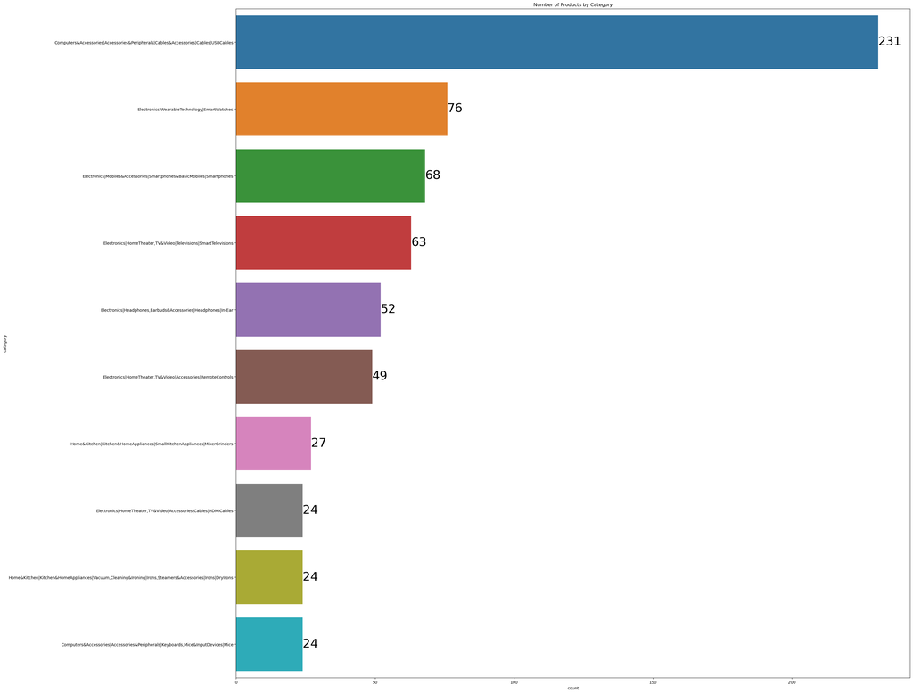

```
Computers&Accessories|Accessories&Peripherals|Cables&Accessories|Cables|USBCables                                          231
Electronics|WearableTechnology|SmartWatches                                                                                 76
Electronics|Mobiles&Accessories|Smartphones&BasicMobiles|Smartphones                                                        68
Electronics|HomeTheater,TV&Video|Televisions|SmartTelevisions                                                               63
Electronics|Headphones,Earbuds&Accessories|Headphones|In-Ear                                                                52
                                                                                                                          ...
Electronics|Cameras&Photography|Accessories|Batteries&Chargers|BatteryChargers                                               1
Computers&Accessories|NetworkingDevices|DataCards&Dongles                                                                    1
Electronics|HomeAudio|Speakers|MultimediaSpeakerSystems                                                                      1
OfficeProducts|OfficePaperProducts|Paper|Copy&PrintingPaper|ColouredPaper                                                    1
Home&Kitchen|Kitchen&HomeAppliances|Vacuum,Cleaning&Ironing|Vacuums&FloorCare|VacuumAccessories|VacuumBags|HandheldBags      1
Name: category, Length: 211, dtype: int64
```

```python
import seaborn as sns

cat_total = amazonSales_1['category'].value_counts()

# Distribution of products across categories
plt.figure(figsize=(30, 30))
ax = sns.countplot(data=amazonSales_1, y='category', order = amazonSales_1['category'].value_counts().index[:10])
ax.bar_label(ax.containers[0], fontsize=30)
plt.title('Number of Products by Category')
plt.show()

cat_total
```

### Since the category titles are very long, and Amazon shows every category and subcategory added together, we can extract just the last word in the category title. So the most occuring category is "USBCables". Let's write a function that takes care of that for us

```python
def extract_last_word(categories):
    # This list will store the last words for each category
    last_words = []

    # Iterate over each category in the input list
    for category in categories:
        # Split the category by '|' and take the last element
        last_word = category.split('|')[-1]
        # Add the last word to the list
        last_words.append(last_word)

    return last_words
```

### Here, we will add a new column that has the shortened category names with just the main category title.

```python
amazonSales_1['shortened_cats'] = extract_last_word(amazonSales_1['category'])
```

### Now let's rerun the graph to show a neater version that has only the main category title. We'll also increase the font sizes for the labels to make it more readable (making the figsize smaller helps with this too).

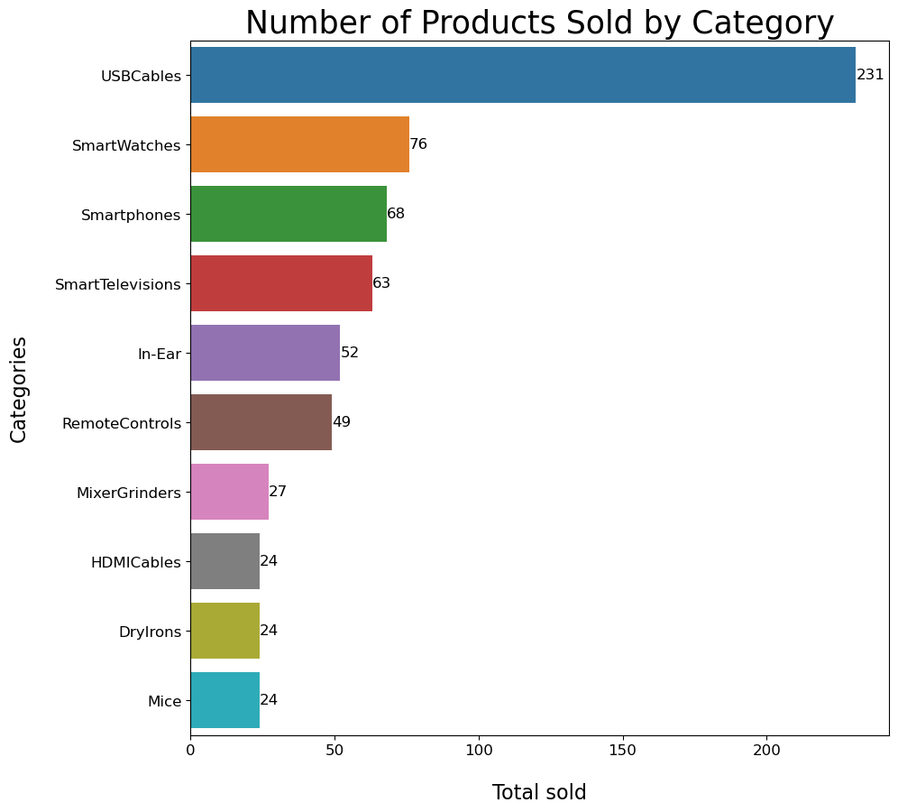

```python
import seaborn as sns

cat_total = amazonSales_1['shortened_cats'].value_counts()

# Distribution of products across categories
plt.figure(figsize=(10, 10))
ax = sns.countplot(data=amazonSales_1, y='shortened_cats', order = cat_total.index[:10])
ax.bar_label(ax.containers[0], fontsize=12)

# Changing font size to make it more readable
current_labels_x = ax.get_xticklabels()
ax.set_xticklabels(current_labels_x, fontsize=12)
current_labels_y = ax.get_yticklabels()
ax.set_yticklabels(current_labels_y, fontsize=12)

# Adding X and Y axis labels and font sizes
ax.set_xlabel('Total sold', fontsize=16, labelpad=20)
ax.set_ylabel('Categories', fontsize=16, labelpad=20)

plt.title('Number of Products Sold by Category', fontsize=25)
plt.show();
```